# Social support and food insecurity

# SDQ trajectories by food insecurity x social support

Total sample (i.e. unique IDs) = 2041  
3-level food insecurity is combined with 2-level enough help to get a 6-level food*social support measure “food_help”.

| Subscale | sweep | N | mean | SD | median | IQR |
| --- | --- | --- | --- | --- | --- | --- |
| SDQ_Conduct | De | 2027 | 1.608 | 1.349 | 1 | 1 |
| SDQ_Conduct | Df | 2036 | 1.464 | 1.391 | 1 | 2 |
| SDQ_Conduct | Dg | 2035 | 1.362 | 1.402 | 1 | 2 |
| SDQ_Conduct | Dh | 2032 | 1.154 | 1.372 | 1 | 2 |
| SDQ_Conduct | Di | 2010 | 1.165 | 1.464 | 1 | 2 |
| SDQ_Conduct | Dj | 1952 | 1.067 | 1.404 | 1 | 2 |
| SDQ_Hyper | De | 2027 | 3.463 | 2.252 | 3 | 3 |
| SDQ_Hyper | Df | 2036 | 3.312 | 2.348 | 3 | 4 |
| SDQ_Hyper | Dg | 2035 | 3.275 | 2.446 | 3 | 4 |
| SDQ_Hyper | Dh | 2032 | 2.839 | 2.333 | 2 | 3 |
| SDQ_Hyper | Di | 2010 | 2.766 | 2.330 | 2 | 3 |
| SDQ_Hyper | Dj | 1952 | 2.538 | 2.299 | 2 | 3 |
| SDQ_Peer | De | 2027 | 0.913 | 1.252 | 0 | 1 |
| SDQ_Peer | Df | 2036 | 0.839 | 1.268 | 0 | 1 |
| SDQ_Peer | Dg | 2035 | 0.996 | 1.421 | 0 | 1 |
| SDQ_Peer | Dh | 2032 | 1.119 | 1.588 | 0 | 2 |
| SDQ_Peer | Di | 2010 | 1.343 | 1.778 | 1 | 2 |
| SDQ_Peer | Dj | 1952 | 1.437 | 1.755 | 1 | 2 |

|  | Not at all.Enough | A little.Enough | A little.Not enough | A lot/fair amount.Enough | A lot/fair amount.Not enough | Not at all.Not enough |
| --- | --- | --- | --- | --- | --- | --- |
| De | 985 | 483 | 146 | 143 | 68 | 202 |
| Df | 989 | 485 | 147 | 144 | 68 | 203 |
| Dg | 989 | 485 | 147 | 144 | 68 | 202 |
| Dh | 987 | 486 | 145 | 144 | 68 | 202 |
| Di | 976 | 485 | 144 | 140 | 68 | 197 |
| Dj | 950 | 473 | 140 | 134 | 67 | 188 |

## Conduct problems

### No covariates

**Estimates**

[1] “No singular fit” [1] “No convergence issues”

| REML |
| --- |
| 39092.73 |

|  | Dsdco1 |  |  |  |  |  |  |  |  |  |  |
| --- | --- | --- | --- | --- | --- | --- | --- | --- | --- | --- | --- |
| Predictors | Estimates | std. Error | std. Beta | standardized std. Error | CI | standardized CI | Statistic | std. Statistic | p | std. p | df |
| (Intercept) | 1.14 | 0.04 | -0.22 | 0.03 | 1.07 – 1.22 | -0.27 – -0.17 | 29.81 | -8.77 | **<0.001** | **<0.001** | 12070.00 |
| food help [A little.Enough] | 0.10 | 0.07 | 0.07 | 0.04 | -0.03 – 0.23 | -0.02 – 0.15 | 1.58 | 1.58 | 0.115 | 0.114 | 12070.00 |
| food help [A little.Not enough] | 0.35 | 0.11 | 0.23 | 0.07 | 0.15 – 0.56 | 0.10 – 0.37 | 3.33 | 3.33 | **0.001** | **0.001** | 12070.00 |
| food help [A lot/fair amount.Enough] | 0.55 | 0.10 | 0.36 | 0.07 | 0.35 – 0.75 | 0.23 – 0.50 | 5.28 | 5.28 | **<0.001** | **<0.001** | 12070.00 |
| food help [A lot/fair amount.Not enough] | 0.73 | 0.15 | 0.48 | 0.10 | 0.44 – 1.01 | 0.29 – 0.67 | 5.00 | 5.00 | **<0.001** | **<0.001** | 12070.00 |
| food help [Not at all.Not enough] | 0.17 | 0.09 | 0.12 | 0.06 | -0.01 – 0.36 | -0.00 – 0.23 | 1.88 | 1.88 | 0.060 | 0.060 | 12070.00 |
| age cent | -0.05 | 0.01 | -0.12 | 0.01 | -0.06 – -0.04 | -0.14 – -0.09 | -9.31 | -9.31 | **<0.001** | **<0.001** | 12070.00 |
| age cent^2 | 0.00 | 0.00 | 0.03 | 0.01 | 0.00 – 0.01 | 0.00 – 0.05 | 2.36 | 2.36 | **0.018** | **0.018** | 12070.00 |
| food help [A little.Enough] × age cent | -0.02 | 0.01 | -0.04 | 0.02 | -0.03 – 0.00 | -0.08 – 0.00 | -1.77 | -1.78 | 0.077 | 0.075 | 12070.00 |
| food help [A little.Not enough] × age cent | -0.01 | 0.01 | -0.02 | 0.03 | -0.04 – 0.02 | -0.09 – 0.05 | -0.57 | -0.56 | 0.568 | 0.573 | 12070.00 |
| food help [A lot/fair amount.Enough] × age cent | 0.00 | 0.01 | 0.01 | 0.03 | -0.03 – 0.03 | -0.06 – 0.07 | 0.16 | 0.16 | 0.875 | 0.874 | 12070.00 |
| food help [A lot/fair amount.Not enough] × age cent | -0.02 | 0.02 | -0.04 | 0.05 | -0.06 – 0.02 | -0.13 – 0.05 | -0.86 | -0.87 | 0.391 | 0.385 | 12070.00 |
| food help [Not at all.Not enough] × age cent | 0.01 | 0.01 | 0.03 | 0.03 | -0.01 – 0.04 | -0.03 – 0.09 | 1.02 | 1.03 | 0.307 | 0.305 | 12070.00 |
| food help [A little.Enough] × age cent^2 | 0.01 | 0.00 | 0.05 | 0.02 | 0.00 – 0.01 | 0.02 – 0.09 | 2.88 | 2.88 | **0.004** | **0.004** | 12070.00 |
| food help [A little.Not enough] × age cent^2 | -0.00 | 0.00 | -0.04 | 0.03 | -0.01 – 0.00 | -0.09 – 0.02 | -1.33 | -1.33 | 0.183 | 0.183 | 12070.00 |
| food help [A lot/fair amount.Enough] × age cent^2 | -0.00 | 0.00 | -0.01 | 0.03 | -0.01 – 0.00 | -0.06 – 0.04 | -0.48 | -0.48 | 0.631 | 0.631 | 12070.00 |
| food help [A lot/fair amount.Not enough] × age cent^2 | 0.01 | 0.00 | 0.10 | 0.04 | 0.00 – 0.02 | 0.03 – 0.17 | 2.75 | 2.75 | **0.006** | **0.006** | 12070.00 |
| food help [Not at all.Not enough] × age cent^2 | -0.00 | 0.00 | -0.03 | 0.03 | -0.01 – 0.00 | -0.08 – 0.02 | -1.28 | -1.28 | 0.201 | 0.201 | 12070.00 |
| Random Effects |  |  |  |  |  |  |  |  |  |  |  |
| σ<sup>2</sup> | 0.81 |  |  |  |  |  |  |  |  |  |  |
| τ<sub>00</sub> <sub>Idnumber</sub> | 1.03 |  |  |  |  |  |  |  |  |  |  |
| τ<sub>11</sub> <sub>Idnumber.age.cent</sub> | 0.01 |  |  |  |  |  |  |  |  |  |  |
| ρ<sub>01</sub> <sub>Idnumber</sub> | 0.12 |  |  |  |  |  |  |  |  |  |  |
| ICC | 0.60 |  |  |  |  |  |  |  |  |  |  |
| N <sub>Idnumber</sub> | 2041 |  |  |  |  |  |  |  |  |  |  |
| Observations | 12092 |  |  |  |  |  |  |  |  |  |  |
| Marginal R<sup>2</sup> / Conditional R<sup>2</sup> | 0.036 / 0.612 |  |  |  |  |  |  |  |  |  |  |

**Contrasts**

| Age | contrast | null.value | estimate | std.error | df | statistic | p.value |
| --- | --- | --- | --- | --- | --- | --- | --- |
| 5 | Not at all.Not enough vs Enough | 0 | 0.043 | 0.101 | 2556.394 | 0.422 | 0.673 |
| 5 | A little.Not enough vs Enough | 0 | 0.010 | 0.122 | 2466.939 | 0.086 | 0.932 |
| 5 | A lot/fair amount.Not enough vs Enough | 0 | 0.510 | 0.185 | 2164.015 | 2.753 | 0.006 |
| 6 | Not at all.Not enough vs Enough | 0 | 0.087 | 0.091 | 2143.077 | 0.954 | 0.340 |
| 6 | A little.Not enough vs Enough | 0 | 0.103 | 0.111 | 2088.618 | 0.929 | 0.353 |
| 6 | A lot/fair amount.Not enough vs Enough | 0 | 0.387 | 0.170 | 1922.791 | 2.285 | 0.022 |
| 7 | Not at all.Not enough vs Enough | 0 | 0.123 | 0.089 | 2288.470 | 1.388 | 0.165 |
| 7 | A little.Not enough vs Enough | 0 | 0.173 | 0.108 | 2232.965 | 1.606 | 0.108 |
| 7 | A lot/fair amount.Not enough vs Enough | 0 | 0.292 | 0.165 | 2055.937 | 1.773 | 0.076 |
| 8 | Not at all.Not enough vs Enough | 0 | 0.151 | 0.090 | 2689.416 | 1.677 | 0.094 |
| 8 | A little.Not enough vs Enough | 0 | 0.220 | 0.109 | 2617.671 | 2.019 | 0.044 |
| 8 | A lot/fair amount.Not enough vs Enough | 0 | 0.224 | 0.166 | 2356.606 | 1.350 | 0.177 |
| 9 | Not at all.Not enough vs Enough | 0 | 0.171 | 0.092 | 3013.335 | 1.848 | 0.065 |
| 9 | A little.Not enough vs Enough | 0 | 0.246 | 0.112 | 2929.490 | 2.196 | 0.028 |
| 9 | A lot/fair amount.Not enough vs Enough | 0 | 0.184 | 0.169 | 2593.241 | 1.085 | 0.278 |
| 10 | Not at all.Not enough vs Enough | 0 | 0.182 | 0.094 | 3028.735 | 1.937 | 0.053 |
| 10 | A little.Not enough vs Enough | 0 | 0.249 | 0.114 | 2947.204 | 2.181 | 0.029 |
| 10 | A lot/fair amount.Not enough vs Enough | 0 | 0.171 | 0.172 | 2604.633 | 0.989 | 0.323 |
| 11 | Not at all.Not enough vs Enough | 0 | 0.185 | 0.095 | 2750.335 | 1.952 | 0.051 |
| 11 | A little.Not enough vs Enough | 0 | 0.229 | 0.115 | 2681.075 | 1.987 | 0.047 |
| 11 | A lot/fair amount.Not enough vs Enough | 0 | 0.185 | 0.175 | 2401.227 | 1.055 | 0.292 |
| 12 | Not at all.Not enough vs Enough | 0 | 0.181 | 0.096 | 2393.299 | 1.871 | 0.061 |
| 12 | A little.Not enough vs Enough | 0 | 0.187 | 0.117 | 2332.327 | 1.599 | 0.110 |
| 12 | A lot/fair amount.Not enough vs Enough | 0 | 0.226 | 0.179 | 2134.409 | 1.264 | 0.206 |
| 13 | Not at all.Not enough vs Enough | 0 | 0.168 | 0.101 | 2216.368 | 1.663 | 0.096 |
| 13 | A little.Not enough vs Enough | 0 | 0.123 | 0.122 | 2144.430 | 1.009 | 0.313 |
| 13 | A lot/fair amount.Not enough vs Enough | 0 | 0.295 | 0.187 | 1985.799 | 1.577 | 0.115 |
| 14 | Not at all.Not enough vs Enough | 0 | 0.146 | 0.111 | 2430.293 | 1.323 | 0.186 |
| 14 | A little.Not enough vs Enough | 0 | 0.036 | 0.133 | 2314.281 | 0.273 | 0.785 |
| 14 | A lot/fair amount.Not enough vs Enough | 0 | 0.391 | 0.203 | 2102.150 | 1.923 | 0.055 |
| 15 | Not at all.Not enough vs Enough | 0 | 0.117 | 0.129 | 3226.340 | 0.909 | 0.363 |
| 15 | A little.Not enough vs Enough | 0 | -0.073 | 0.154 | 3020.921 | -0.471 | 0.638 |
| 15 | A lot/fair amount.Not enough vs Enough | 0 | 0.515 | 0.232 | 2613.763 | 2.222 | 0.026 |
| 16 | Not at all.Not enough vs Enough | 0 | 0.079 | 0.156 | 4727.224 | 0.510 | 0.610 |
| 16 | A little.Not enough vs Enough | 0 | -0.204 | 0.185 | 4404.159 | -1.099 | 0.272 |
| 16 | A lot/fair amount.Not enough vs Enough | 0 | 0.665 | 0.273 | 3644.820 | 2.433 | 0.015 |

**Plot**

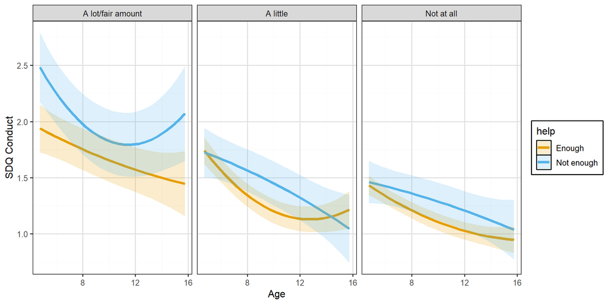

### Covariates sex and income

**Estimates**

[1] “No singular fit” [1] “No convergence issues”

| REML |
| --- |
| 39031.98 |

|  | Dsdco1 |  |  |  |  |  |  |  |  |  |  |
| --- | --- | --- | --- | --- | --- | --- | --- | --- | --- | --- | --- |
| Predictors | Estimates | std. Error | std. Beta | standardized std. Error | CI | standardized CI | Statistic | std. Statistic | p | std. p | df |
| (Intercept) | 1.70 | 0.08 | 0.14 | 0.05 | 1.55 – 1.85 | 0.05 – 0.24 | 22.12 | 2.86 | **<0.001** | **0.004** | 12065.00 |
| food help [A little.Enough] | 0.05 | 0.07 | 0.03 | 0.04 | -0.08 – 0.18 | -0.05 – 0.12 | 0.74 | 0.74 | 0.461 | 0.460 | 12065.00 |
| food help [A little.Not enough] | 0.29 | 0.10 | 0.19 | 0.07 | 0.09 – 0.50 | 0.06 – 0.33 | 2.78 | 2.78 | **0.005** | **0.005** | 12065.00 |
| food help [A lot/fair amount.Enough] | 0.35 | 0.11 | 0.23 | 0.07 | 0.14 – 0.56 | 0.10 – 0.37 | 3.33 | 3.33 | **0.001** | **0.001** | 12065.00 |
| food help [A lot/fair amount.Not enough] | 0.55 | 0.14 | 0.36 | 0.10 | 0.26 – 0.83 | 0.17 – 0.55 | 3.79 | 3.79 | **<0.001** | **<0.001** | 12065.00 |
| food help [Not at all.Not enough] | 0.16 | 0.09 | 0.10 | 0.06 | -0.02 – 0.34 | -0.01 – 0.22 | 1.74 | 1.73 | 0.083 | 0.083 | 12065.00 |
| age cent | -0.05 | 0.01 | -0.11 | 0.01 | -0.06 – -0.04 | -0.14 – -0.09 | -9.26 | -9.26 | **<0.001** | **<0.001** | 12065.00 |
| age cent^2 | 0.00 | 0.00 | 0.03 | 0.01 | 0.00 – 0.01 | 0.00 – 0.05 | 2.37 | 2.37 | **0.018** | **0.018** | 12065.00 |
| Sex [F] | -0.18 | 0.05 | -0.12 | 0.03 | -0.27 – -0.08 | -0.18 – -0.05 | -3.72 | -3.72 | **<0.001** | **<0.001** | 12065.00 |
| DeEqv5 [2] | -0.35 | 0.08 | -0.23 | 0.05 | -0.51 – -0.19 | -0.33 – -0.13 | -4.32 | -4.32 | **<0.001** | **<0.001** | 12065.00 |
| DeEqv5 [3] | -0.49 | 0.08 | -0.32 | 0.05 | -0.66 – -0.33 | -0.43 – -0.22 | -5.93 | -5.93 | **<0.001** | **<0.001** | 12065.00 |
| DeEqv5 [4] | -0.53 | 0.08 | -0.35 | 0.05 | -0.68 – -0.37 | -0.45 – -0.25 | -6.63 | -6.63 | **<0.001** | **<0.001** | 12065.00 |
| DeEqv5 [5] | -0.65 | 0.09 | -0.43 | 0.06 | -0.81 – -0.48 | -0.54 – -0.32 | -7.57 | -7.57 | **<0.001** | **<0.001** | 12065.00 |
| food help [A little.Enough] × age cent | -0.02 | 0.01 | -0.04 | 0.02 | -0.03 – 0.00 | -0.08 – 0.00 | -1.77 | -1.79 | 0.076 | 0.074 | 12065.00 |
| food help [A little.Not enough] × age cent | -0.01 | 0.01 | -0.02 | 0.03 | -0.04 – 0.02 | -0.09 – 0.05 | -0.57 | -0.56 | 0.571 | 0.575 | 12065.00 |
| food help [A lot/fair amount.Enough] × age cent | 0.00 | 0.01 | 0.01 | 0.03 | -0.03 – 0.03 | -0.06 – 0.07 | 0.16 | 0.16 | 0.874 | 0.872 | 12065.00 |
| food help [A lot/fair amount.Not enough] × age cent | -0.02 | 0.02 | -0.04 | 0.05 | -0.06 – 0.02 | -0.13 – 0.05 | -0.85 | -0.86 | 0.394 | 0.388 | 12065.00 |
| food help [Not at all.Not enough] × age cent | 0.01 | 0.01 | 0.03 | 0.03 | -0.01 – 0.04 | -0.03 – 0.09 | 1.02 | 1.02 | 0.308 | 0.306 | 12065.00 |
| food help [A little.Enough] × age cent^2 | 0.01 | 0.00 | 0.05 | 0.02 | 0.00 – 0.01 | 0.02 – 0.09 | 2.88 | 2.88 | **0.004** | **0.004** | 12065.00 |
| food help [A little.Not enough] × age cent^2 | -0.00 | 0.00 | -0.04 | 0.03 | -0.01 – 0.00 | -0.09 – 0.02 | -1.34 | -1.34 | 0.179 | 0.179 | 12065.00 |
| food help [A lot/fair amount.Enough] × age cent^2 | -0.00 | 0.00 | -0.01 | 0.03 | -0.01 – 0.00 | -0.06 – 0.04 | -0.48 | -0.48 | 0.629 | 0.629 | 12065.00 |
| food help [A lot/fair amount.Not enough] × age cent^2 | 0.01 | 0.00 | 0.10 | 0.04 | 0.00 – 0.02 | 0.03 – 0.17 | 2.74 | 2.74 | **0.006** | **0.006** | 12065.00 |
| food help [Not at all.Not enough] × age cent^2 | -0.00 | 0.00 | -0.03 | 0.03 | -0.01 – 0.00 | -0.08 – 0.02 | -1.29 | -1.29 | 0.197 | 0.197 | 12065.00 |
| Random Effects |  |  |  |  |  |  |  |  |  |  |  |
| σ<sup>2</sup> | 0.81 |  |  |  |  |  |  |  |  |  |  |
| τ<sub>00</sub> <sub>Idnumber</sub> | 0.98 |  |  |  |  |  |  |  |  |  |  |
| τ<sub>11</sub> <sub>Idnumber.age.cent</sub> | 0.01 |  |  |  |  |  |  |  |  |  |  |
| ρ<sub>01</sub> <sub>Idnumber</sub> | 0.12 |  |  |  |  |  |  |  |  |  |  |
| ICC | 0.59 |  |  |  |  |  |  |  |  |  |  |
| N <sub>Idnumber</sub> | 2041 |  |  |  |  |  |  |  |  |  |  |
| Observations | 12092 |  |  |  |  |  |  |  |  |  |  |
| Marginal R<sup>2</sup> / Conditional R<sup>2</sup> | 0.057 / 0.612 |  |  |  |  |  |  |  |  |  |  |

**Lowest income plot**

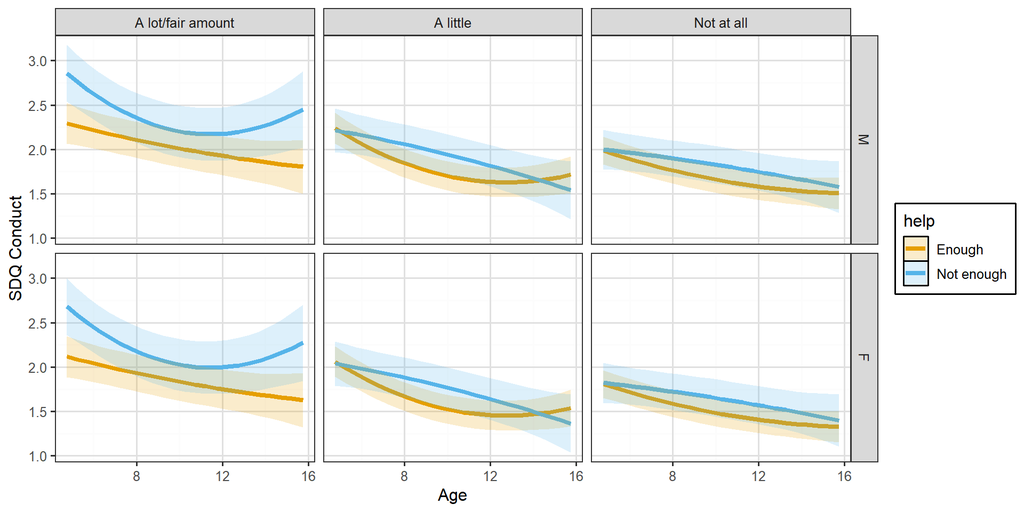

**Highest income plot**

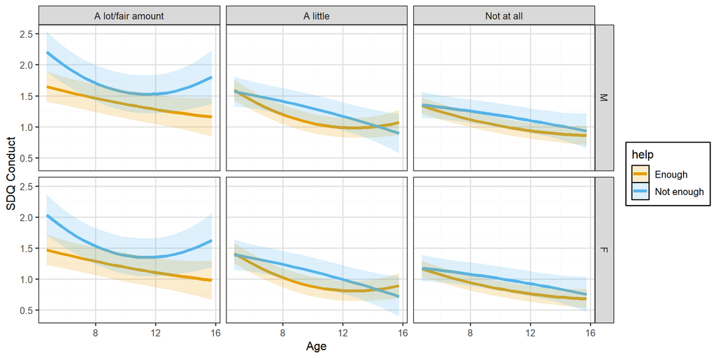

### Sex, income, maternal MH

**Estimates**

[1] “No singular fit” [1] “No convergence issues”

| REML |
| --- |
| 38806.66 |

|  | Dsdco1 |  |  |  |  |  |  |  |  |  |  |
| --- | --- | --- | --- | --- | --- | --- | --- | --- | --- | --- | --- |
| Predictors | Estimates | std. Error | std. Beta | standardized std. Error | CI | standardized CI | Statistic | std. Statistic | p | std. p | df |
| (Intercept) | 1.64 | 0.07 | 0.11 | 0.05 | 1.49 – 1.78 | 0.01 – 0.21 | 21.92 | 2.23 | **<0.001** | **0.026** | 12034.00 |
| food help [A little.Enough] | 0.01 | 0.06 | 0.00 | 0.04 | -0.12 – 0.13 | -0.08 – 0.09 | 0.10 | 0.10 | 0.922 | 0.919 | 12034.00 |
| food help [A little.Not enough] | 0.13 | 0.10 | 0.09 | 0.07 | -0.07 – 0.33 | -0.05 – 0.22 | 1.26 | 1.26 | 0.208 | 0.208 | 12034.00 |
| food help [A lot/fair amount.Enough] | 0.27 | 0.10 | 0.18 | 0.07 | 0.07 – 0.47 | 0.05 – 0.31 | 2.62 | 2.62 | **0.009** | **0.009** | 12034.00 |
| food help [A lot/fair amount.Not enough] | 0.31 | 0.14 | 0.21 | 0.09 | 0.03 – 0.59 | 0.02 – 0.39 | 2.18 | 2.18 | **0.030** | **0.029** | 12034.00 |
| food help [Not at all.Not enough] | 0.10 | 0.09 | 0.07 | 0.06 | -0.08 – 0.28 | -0.05 – 0.18 | 1.12 | 1.11 | 0.265 | 0.265 | 12034.00 |
| age cent | -0.05 | 0.01 | -0.11 | 0.01 | -0.06 – -0.04 | -0.14 – -0.09 | -9.24 | -9.25 | **<0.001** | **<0.001** | 12034.00 |
| age cent^2 | 0.00 | 0.00 | 0.03 | 0.01 | 0.00 – 0.01 | 0.00 – 0.05 | 2.36 | 2.36 | **0.018** | **0.018** | 12034.00 |
| Sex [F] | -0.16 | 0.05 | -0.11 | 0.03 | -0.25 – -0.07 | -0.17 – -0.05 | -3.54 | -3.54 | **<0.001** | **<0.001** | 12034.00 |
| DeEqv5 [2] | -0.29 | 0.08 | -0.19 | 0.05 | -0.44 – -0.13 | -0.29 – -0.09 | -3.65 | -3.65 | **<0.001** | **<0.001** | 12034.00 |
| DeEqv5 [3] | -0.39 | 0.08 | -0.26 | 0.05 | -0.55 – -0.23 | -0.36 – -0.15 | -4.79 | -4.79 | **<0.001** | **<0.001** | 12034.00 |
| DeEqv5 [4] | -0.41 | 0.08 | -0.27 | 0.05 | -0.57 – -0.26 | -0.38 – -0.17 | -5.32 | -5.32 | **<0.001** | **<0.001** | 12034.00 |
| DeEqv5 [5] | -0.51 | 0.08 | -0.34 | 0.06 | -0.68 – -0.35 | -0.45 – -0.23 | -6.15 | -6.15 | **<0.001** | **<0.001** | 12034.00 |
| DeSf12mn | -0.24 | 0.02 | -0.16 | 0.02 | -0.29 – -0.20 | -0.19 – -0.13 | -10.21 | -10.21 | **<0.001** | **<0.001** | 12034.00 |
| food help [A little.Enough] × age cent | -0.02 | 0.01 | -0.04 | 0.02 | -0.03 – 0.00 | -0.08 – 0.00 | -1.75 | -1.76 | 0.081 | 0.078 | 12034.00 |
| food help [A little.Not enough] × age cent | -0.01 | 0.01 | -0.02 | 0.03 | -0.04 – 0.02 | -0.09 – 0.05 | -0.56 | -0.55 | 0.578 | 0.584 | 12034.00 |
| food help [A lot/fair amount.Enough] × age cent | 0.01 | 0.01 | 0.01 | 0.03 | -0.02 – 0.03 | -0.05 – 0.08 | 0.38 | 0.38 | 0.705 | 0.703 | 12034.00 |
| food help [A lot/fair amount.Not enough] × age cent | -0.02 | 0.02 | -0.04 | 0.05 | -0.06 – 0.02 | -0.13 – 0.05 | -0.86 | -0.87 | 0.391 | 0.382 | 12034.00 |
| food help [Not at all.Not enough] × age cent | 0.01 | 0.01 | 0.03 | 0.03 | -0.01 – 0.04 | -0.03 – 0.09 | 0.99 | 0.99 | 0.323 | 0.320 | 12034.00 |
| food help [A little.Enough] × age cent^2 | 0.01 | 0.00 | 0.06 | 0.02 | 0.00 – 0.01 | 0.02 – 0.09 | 3.07 | 3.07 | **0.002** | **0.002** | 12034.00 |
| food help [A little.Not enough] × age cent^2 | -0.00 | 0.00 | -0.04 | 0.03 | -0.01 – 0.00 | -0.09 – 0.02 | -1.33 | -1.33 | 0.183 | 0.183 | 12034.00 |
| food help [A lot/fair amount.Enough] × age cent^2 | -0.00 | 0.00 | -0.01 | 0.03 | -0.01 – 0.00 | -0.07 – 0.04 | -0.55 | -0.55 | 0.581 | 0.581 | 12034.00 |
| food help [A lot/fair amount.Not enough] × age cent^2 | 0.01 | 0.00 | 0.10 | 0.04 | 0.00 – 0.02 | 0.03 – 0.17 | 2.74 | 2.74 | **0.006** | **0.006** | 12034.00 |
| food help [Not at all.Not enough] × age cent^2 | -0.00 | 0.00 | -0.03 | 0.03 | -0.01 – 0.00 | -0.08 – 0.02 | -1.30 | -1.30 | 0.194 | 0.194 | 12034.00 |
| Random Effects |  |  |  |  |  |  |  |  |  |  |  |
| σ<sup>2</sup> | 0.81 |  |  |  |  |  |  |  |  |  |  |
| τ<sub>00</sub> <sub>Idnumber</sub> | 0.92 |  |  |  |  |  |  |  |  |  |  |
| τ<sub>11</sub> <sub>Idnumber.age.cent</sub> | 0.01 |  |  |  |  |  |  |  |  |  |  |
| ρ<sub>01</sub> <sub>Idnumber</sub> | 0.16 |  |  |  |  |  |  |  |  |  |  |
| ICC | 0.57 |  |  |  |  |  |  |  |  |  |  |
| N <sub>Idnumber</sub> | 2035 |  |  |  |  |  |  |  |  |  |  |
| Observations | 12062 |  |  |  |  |  |  |  |  |  |  |
| Marginal R<sup>2</sup> / Conditional R<sup>2</sup> | 0.081 / 0.609 |  |  |  |  |  |  |  |  |  |  |

**Lowest income plot**

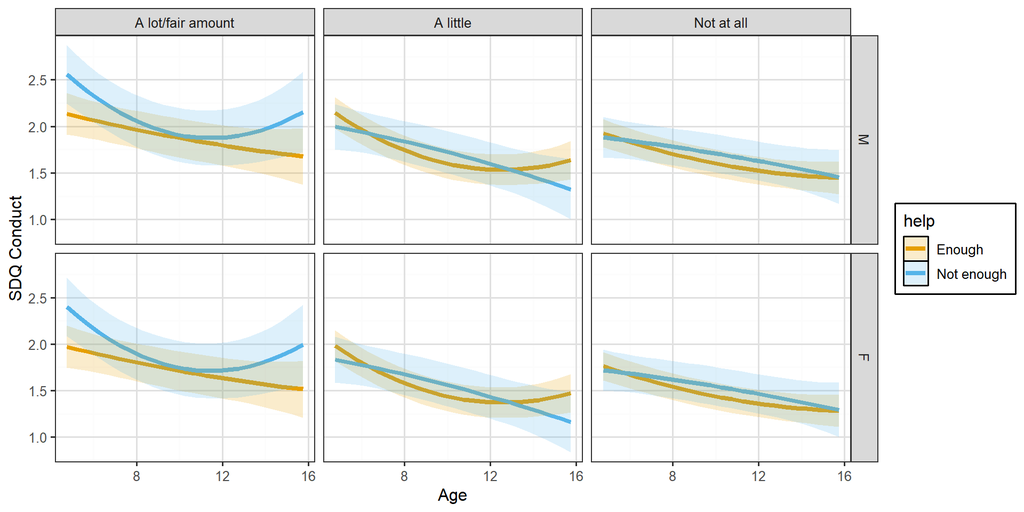

**Highest income plot**

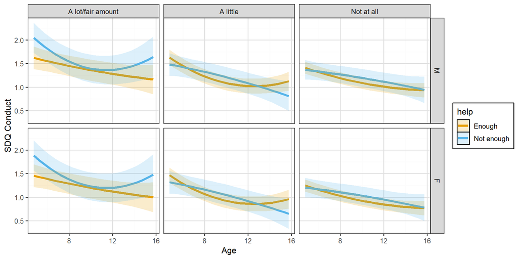

### Sex, income, maternal MH + SIMD

**Estimates**

[1] “No singular fit” [1] “No convergence issues”

| REML |
| --- |
| 38796.09 |

|  | Dsdco1 |  |  |  |  |  |  |  |  |  |  |
| --- | --- | --- | --- | --- | --- | --- | --- | --- | --- | --- | --- |
| Predictors | Estimates | std. Error | std. Beta | standardized std. Error | CI | standardized CI | Statistic | std. Statistic | p | std. p | df |
| (Intercept) | 1.45 | 0.09 | -0.01 | 0.06 | 1.27 – 1.63 | -0.13 – 0.11 | 15.84 | -0.21 | **<0.001** | 0.835 | 12030.00 |
| food help [A little.Enough] | 0.01 | 0.06 | 0.01 | 0.04 | -0.11 – 0.14 | -0.07 – 0.09 | 0.21 | 0.21 | 0.835 | 0.833 | 12030.00 |
| food help [A little.Not enough] | 0.13 | 0.10 | 0.09 | 0.07 | -0.07 – 0.33 | -0.05 – 0.22 | 1.28 | 1.28 | 0.201 | 0.201 | 12030.00 |
| food help [A lot/fair amount.Enough] | 0.26 | 0.10 | 0.17 | 0.07 | 0.05 – 0.46 | 0.04 – 0.30 | 2.48 | 2.48 | **0.013** | **0.013** | 12030.00 |
| food help [A lot/fair amount.Not enough] | 0.31 | 0.14 | 0.20 | 0.09 | 0.03 – 0.59 | 0.02 – 0.39 | 2.15 | 2.15 | **0.032** | **0.032** | 12030.00 |
| food help [Not at all.Not enough] | 0.11 | 0.09 | 0.07 | 0.06 | -0.07 – 0.28 | -0.04 – 0.19 | 1.22 | 1.22 | 0.221 | 0.222 | 12030.00 |
| age cent | -0.05 | 0.01 | -0.11 | 0.01 | -0.06 – -0.04 | -0.14 – -0.09 | -9.22 | -9.23 | **<0.001** | **<0.001** | 12030.00 |
| age cent^2 | 0.00 | 0.00 | 0.03 | 0.01 | 0.00 – 0.01 | 0.00 – 0.05 | 2.37 | 2.37 | **0.018** | **0.018** | 12030.00 |
| Sex [F] | -0.17 | 0.05 | -0.11 | 0.03 | -0.26 – -0.08 | -0.17 – -0.05 | -3.71 | -3.71 | **<0.001** | **<0.001** | 12030.00 |
| DeEqv5 [2] | -0.25 | 0.08 | -0.17 | 0.05 | -0.40 – -0.10 | -0.27 – -0.06 | -3.17 | -3.17 | **0.002** | **0.002** | 12030.00 |
| DeEqv5 [3] | -0.32 | 0.08 | -0.21 | 0.05 | -0.48 – -0.16 | -0.32 – -0.11 | -3.90 | -3.90 | **<0.001** | **<0.001** | 12030.00 |
| DeEqv5 [4] | -0.31 | 0.08 | -0.20 | 0.05 | -0.47 – -0.15 | -0.31 – -0.10 | -3.80 | -3.80 | **<0.001** | **<0.001** | 12030.00 |
| DeEqv5 [5] | -0.38 | 0.09 | -0.25 | 0.06 | -0.56 – -0.21 | -0.37 – -0.14 | -4.35 | -4.35 | **<0.001** | **<0.001** | 12030.00 |
| DeSf12mn | -0.24 | 0.02 | -0.16 | 0.02 | -0.28 – -0.19 | -0.19 – -0.13 | -9.97 | -9.97 | **<0.001** | **<0.001** | 12030.00 |
| ALeSNim2 [2] | 0.01 | 0.07 | 0.01 | 0.04 | -0.12 – 0.14 | -0.08 – 0.09 | 0.12 | 0.12 | 0.907 | 0.907 | 12030.00 |
| ALeSNim2 [3] | 0.19 | 0.07 | 0.12 | 0.05 | 0.05 – 0.32 | 0.03 – 0.21 | 2.66 | 2.66 | **0.008** | **0.008** | 12030.00 |
| ALeSNim2 [4] | 0.15 | 0.08 | 0.10 | 0.05 | 0.00 – 0.30 | 0.00 – 0.20 | 1.98 | 1.98 | **0.047** | **0.047** | 12030.00 |
| ALeSNim2 [5] | 0.36 | 0.08 | 0.24 | 0.06 | 0.20 – 0.53 | 0.13 – 0.35 | 4.30 | 4.30 | **<0.001** | **<0.001** | 12030.00 |
| food help [A little.Enough] × age cent | -0.02 | 0.01 | -0.04 | 0.02 | -0.03 – 0.00 | -0.08 – 0.00 | -1.75 | -1.77 | 0.080 | 0.078 | 12030.00 |
| food help [A little.Not enough] × age cent | -0.01 | 0.01 | -0.02 | 0.03 | -0.04 – 0.02 | -0.09 – 0.05 | -0.55 | -0.55 | 0.579 | 0.585 | 12030.00 |
| food help [A lot/fair amount.Enough] × age cent | 0.01 | 0.01 | 0.01 | 0.03 | -0.02 – 0.03 | -0.05 – 0.08 | 0.38 | 0.39 | 0.702 | 0.700 | 12030.00 |
| food help [A lot/fair amount.Not enough] × age cent | -0.02 | 0.02 | -0.04 | 0.05 | -0.06 – 0.02 | -0.13 – 0.05 | -0.86 | -0.87 | 0.392 | 0.384 | 12030.00 |
| food help [Not at all.Not enough] × age cent | 0.01 | 0.01 | 0.03 | 0.03 | -0.01 – 0.04 | -0.03 – 0.09 | 0.99 | 0.99 | 0.324 | 0.321 | 12030.00 |
| food help [A little.Enough] × age cent^2 | 0.01 | 0.00 | 0.06 | 0.02 | 0.00 – 0.01 | 0.02 – 0.09 | 3.07 | 3.07 | **0.002** | **0.002** | 12030.00 |
| food help [A little.Not enough] × age cent^2 | -0.00 | 0.00 | -0.04 | 0.03 | -0.01 – 0.00 | -0.09 – 0.02 | -1.33 | -1.33 | 0.183 | 0.183 | 12030.00 |
| food help [A lot/fair amount.Enough] × age cent^2 | -0.00 | 0.00 | -0.01 | 0.03 | -0.01 – 0.00 | -0.07 – 0.04 | -0.56 | -0.56 | 0.579 | 0.579 | 12030.00 |
| food help [A lot/fair amount.Not enough] × age cent^2 | 0.01 | 0.00 | 0.10 | 0.04 | 0.00 – 0.02 | 0.03 – 0.17 | 2.74 | 2.74 | **0.006** | **0.006** | 12030.00 |
| food help [Not at all.Not enough] × age cent^2 | -0.00 | 0.00 | -0.03 | 0.03 | -0.01 – 0.00 | -0.08 – 0.02 | -1.30 | -1.30 | 0.194 | 0.194 | 12030.00 |
| Random Effects |  |  |  |  |  |  |  |  |  |  |  |
| σ<sup>2</sup> | 0.81 |  |  |  |  |  |  |  |  |  |  |
| τ<sub>00</sub> <sub>Idnumber</sub> | 0.91 |  |  |  |  |  |  |  |  |  |  |
| τ<sub>11</sub> <sub>Idnumber.age.cent</sub> | 0.01 |  |  |  |  |  |  |  |  |  |  |
| ρ<sub>01</sub> <sub>Idnumber</sub> | 0.17 |  |  |  |  |  |  |  |  |  |  |
| ICC | 0.57 |  |  |  |  |  |  |  |  |  |  |
| N <sub>Idnumber</sub> | 2035 |  |  |  |  |  |  |  |  |  |  |
| Observations | 12062 |  |  |  |  |  |  |  |  |  |  |
| Marginal R<sup>2</sup> / Conditional R<sup>2</sup> | 0.087 / 0.610 |  |  |  |  |  |  |  |  |  |  |

**Contrasts**

| Age | contrast | null.value | estimate | std.error | df | statistic | p.value |
| --- | --- | --- | --- | --- | --- | --- | --- |
| 5 | Not at all.Not enough vs Enough | 0 | -0.022 | 0.097 | 2578.824 | -0.223 | 0.824 |
| 5 | A little.Not enough vs Enough | 0 | -0.128 | 0.118 | 2503.264 | -1.083 | 0.279 |
| 5 | A lot/fair amount.Not enough vs Enough | 0 | 0.400 | 0.177 | 2151.872 | 2.258 | 0.024 |
| 6 | Not at all.Not enough vs Enough | 0 | 0.023 | 0.087 | 2126.999 | 0.261 | 0.794 |
| 6 | A little.Not enough vs Enough | 0 | -0.032 | 0.106 | 2085.886 | -0.301 | 0.763 |
| 6 | A lot/fair amount.Not enough vs Enough | 0 | 0.272 | 0.161 | 1888.862 | 1.691 | 0.091 |
| 7 | Not at all.Not enough vs Enough | 0 | 0.059 | 0.084 | 2287.736 | 0.694 | 0.488 |
| 7 | A little.Not enough vs Enough | 0 | 0.040 | 0.103 | 2239.022 | 0.393 | 0.695 |
| 7 | A lot/fair amount.Not enough vs Enough | 0 | 0.173 | 0.157 | 2035.149 | 1.103 | 0.270 |
| 8 | Not at all.Not enough vs Enough | 0 | 0.086 | 0.086 | 2730.199 | 1.001 | 0.317 |
| 8 | A little.Not enough vs Enough | 0 | 0.090 | 0.105 | 2654.772 | 0.854 | 0.393 |
| 8 | A lot/fair amount.Not enough vs Enough | 0 | 0.101 | 0.159 | 2366.120 | 0.638 | 0.524 |
| 9 | Not at all.Not enough vs Enough | 0 | 0.105 | 0.089 | 3081.813 | 1.189 | 0.235 |
| 9 | A little.Not enough vs Enough | 0 | 0.116 | 0.108 | 2988.727 | 1.068 | 0.285 |
| 9 | A lot/fair amount.Not enough vs Enough | 0 | 0.057 | 0.163 | 2623.831 | 0.352 | 0.725 |
| 10 | Not at all.Not enough vs Enough | 0 | 0.116 | 0.091 | 3088.055 | 1.283 | 0.200 |
| 10 | A little.Not enough vs Enough | 0 | 0.118 | 0.111 | 3002.249 | 1.069 | 0.285 |
| 10 | A lot/fair amount.Not enough vs Enough | 0 | 0.041 | 0.167 | 2631.370 | 0.247 | 0.805 |
| 11 | Not at all.Not enough vs Enough | 0 | 0.119 | 0.092 | 2777.598 | 1.294 | 0.196 |
| 11 | A little.Not enough vs Enough | 0 | 0.098 | 0.112 | 2714.348 | 0.871 | 0.384 |
| 11 | A lot/fair amount.Not enough vs Enough | 0 | 0.053 | 0.170 | 2408.386 | 0.310 | 0.757 |
| 12 | Not at all.Not enough vs Enough | 0 | 0.114 | 0.094 | 2392.615 | 1.209 | 0.227 |
| 12 | A little.Not enough vs Enough | 0 | 0.054 | 0.114 | 2345.288 | 0.472 | 0.637 |
| 12 | A lot/fair amount.Not enough vs Enough | 0 | 0.092 | 0.174 | 2124.662 | 0.527 | 0.598 |
| 13 | Not at all.Not enough vs Enough | 0 | 0.100 | 0.098 | 2205.511 | 1.012 | 0.312 |
| 13 | A little.Not enough vs Enough | 0 | -0.013 | 0.120 | 2149.829 | -0.108 | 0.914 |
| 13 | A lot/fair amount.Not enough vs Enough | 0 | 0.159 | 0.183 | 1971.163 | 0.868 | 0.386 |
| 14 | Not at all.Not enough vs Enough | 0 | 0.077 | 0.109 | 2425.433 | 0.711 | 0.477 |
| 14 | A little.Not enough vs Enough | 0 | -0.103 | 0.131 | 2325.419 | -0.784 | 0.433 |
| 14 | A lot/fair amount.Not enough vs Enough | 0 | 0.254 | 0.200 | 2094.026 | 1.267 | 0.205 |
| 15 | Not at all.Not enough vs Enough | 0 | 0.047 | 0.127 | 3237.698 | 0.368 | 0.713 |
| 15 | A little.Not enough vs Enough | 0 | -0.216 | 0.153 | 3047.621 | -1.418 | 0.156 |
| 15 | A lot/fair amount.Not enough vs Enough | 0 | 0.376 | 0.229 | 2620.577 | 1.642 | 0.101 |
| 16 | Not at all.Not enough vs Enough | 0 | 0.008 | 0.155 | 4754.150 | 0.052 | 0.959 |
| 16 | A little.Not enough vs Enough | 0 | -0.353 | 0.184 | 4447.785 | -1.915 | 0.056 |
| 16 | A lot/fair amount.Not enough vs Enough | 0 | 0.526 | 0.272 | 3670.720 | 1.936 | 0.053 |

**Lowest income plot**

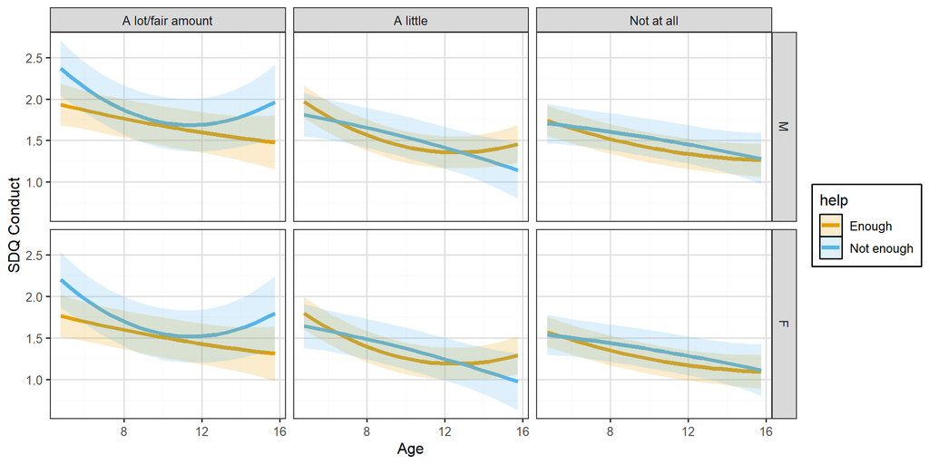

**Highest income plot**

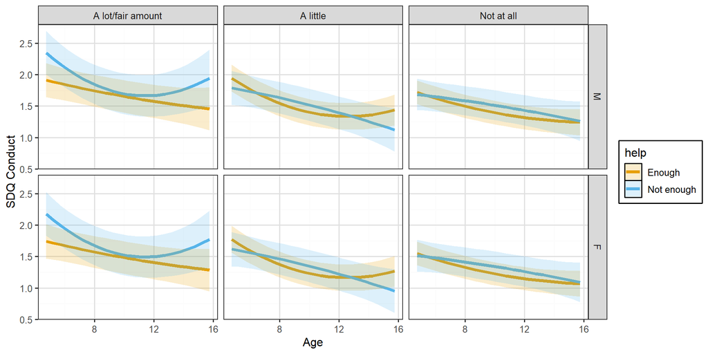

## Emotional problems

### No covariates

**Estimates**

[1] “No singular fit” [1] “No convergence issues”

| REML |
| --- |
| 45198.1 |

|  | Dsdem1 |  |  |  |  |  |  |  |  |  |  |
| --- | --- | --- | --- | --- | --- | --- | --- | --- | --- | --- | --- |
| Predictors | Estimates | std. Error | std. Beta | standardized std. Error | CI | standardized CI | Statistic | std. Statistic | p | std. p | df |
| (Intercept) | 1.30 | 0.05 | -0.18 | 0.02 | 1.21 – 1.39 | -0.23 – -0.13 | 27.33 | -7.43 | **<0.001** | **<0.001** | 12064.00 |
| food help [A little.Enough] | 0.20 | 0.08 | 0.11 | 0.04 | 0.04 – 0.37 | 0.02 – 0.19 | 2.50 | 2.49 | **0.013** | **0.013** | 12064.00 |
| food help [A little.Not enough] | 0.76 | 0.13 | 0.39 | 0.07 | 0.50 – 1.02 | 0.26 – 0.53 | 5.78 | 5.78 | **<0.001** | **<0.001** | 12064.00 |
| food help [A lot/fair amount.Enough] | 0.71 | 0.13 | 0.37 | 0.07 | 0.46 – 0.96 | 0.24 – 0.50 | 5.55 | 5.55 | **<0.001** | **<0.001** | 12064.00 |
| food help [A lot/fair amount.Not enough] | 1.17 | 0.18 | 0.60 | 0.09 | 0.81 – 1.52 | 0.42 – 0.79 | 6.50 | 6.50 | **<0.001** | **<0.001** | 12064.00 |
| food help [Not at all.Not enough] | 0.29 | 0.12 | 0.15 | 0.06 | 0.07 – 0.52 | 0.04 – 0.27 | 2.55 | 2.55 | **0.011** | **0.011** | 12064.00 |
| age cent | 0.10 | 0.01 | 0.17 | 0.03 | 0.07 – 0.12 | 0.12 – 0.22 | 6.67 | 6.67 | **<0.001** | **<0.001** | 12064.00 |
| age cent^2 | 0.00 | 0.00 | 0.01 | 0.01 | -0.00 – 0.01 | -0.01 – 0.04 | 0.97 | 0.99 | 0.331 | 0.320 | 12064.00 |
| age cent^3 | -0.00 | 0.00 | -0.04 | 0.01 | -0.00 – -0.00 | -0.07 – -0.01 | -2.80 | -2.80 | **0.005** | **0.005** | 12064.00 |
| food help [A little.Enough] × age cent | 0.02 | 0.02 | 0.04 | 0.04 | -0.03 – 0.07 | -0.05 – 0.13 | 0.90 | 0.90 | 0.370 | 0.369 | 12064.00 |
| food help [A little.Not enough] × age cent | 0.02 | 0.04 | 0.03 | 0.07 | -0.06 – 0.09 | -0.10 – 0.17 | 0.46 | 0.47 | 0.642 | 0.636 | 12064.00 |
| food help [A lot/fair amount.Enough] × age cent | -0.02 | 0.04 | -0.03 | 0.06 | -0.09 – 0.05 | -0.16 – 0.10 | -0.47 | -0.47 | 0.638 | 0.640 | 12064.00 |
| food help [A lot/fair amount.Not enough] × age cent | -0.02 | 0.05 | -0.03 | 0.09 | -0.12 – 0.08 | -0.21 – 0.15 | -0.36 | -0.35 | 0.720 | 0.723 | 12064.00 |
| food help [Not at all.Not enough] × age cent | 0.06 | 0.03 | 0.11 | 0.06 | -0.01 – 0.13 | -0.01 – 0.23 | 1.79 | 1.79 | 0.074 | 0.073 | 12064.00 |
| food help [A little.Enough] × age cent^2 | -0.00 | 0.00 | -0.00 | 0.02 | -0.01 – 0.01 | -0.04 – 0.04 | -0.17 | -0.17 | 0.863 | 0.866 | 12064.00 |
| food help [A little.Not enough] × age cent^2 | -0.02 | 0.01 | -0.11 | 0.03 | -0.03 – -0.01 | -0.18 – -0.05 | -3.38 | -3.37 | **0.001** | **0.001** | 12064.00 |
| food help [A lot/fair amount.Enough] × age cent^2 | -0.01 | 0.00 | -0.04 | 0.03 | -0.02 – 0.00 | -0.10 – 0.02 | -1.39 | -1.39 | 0.164 | 0.163 | 12064.00 |
| food help [A lot/fair amount.Not enough] × age cent^2 | -0.01 | 0.01 | -0.08 | 0.04 | -0.02 – 0.00 | -0.16 – 0.00 | -1.85 | -1.85 | 0.065 | 0.065 | 12064.00 |
| food help [Not at all.Not enough] × age cent^2 | -0.00 | 0.00 | -0.02 | 0.03 | -0.01 – 0.01 | -0.08 – 0.04 | -0.66 | -0.65 | 0.508 | 0.514 | 12064.00 |
| food help [A little.Enough] × age cent^3 | -0.00 | 0.00 | -0.01 | 0.02 | -0.00 – 0.00 | -0.05 – 0.04 | -0.24 | -0.24 | 0.812 | 0.812 | 12064.00 |
| food help [A little.Not enough] × age cent^3 | 0.00 | 0.00 | 0.03 | 0.04 | -0.00 – 0.00 | -0.05 – 0.10 | 0.71 | 0.71 | 0.481 | 0.481 | 12064.00 |
| food help [A lot/fair amount.Enough] × age cent^3 | 0.00 | 0.00 | 0.03 | 0.03 | -0.00 – 0.00 | -0.04 – 0.10 | 0.89 | 0.89 | 0.376 | 0.376 | 12064.00 |
| food help [A lot/fair amount.Not enough] × age cent^3 | 0.00 | 0.00 | 0.04 | 0.05 | -0.00 – 0.01 | -0.05 – 0.14 | 0.85 | 0.85 | 0.394 | 0.394 | 12064.00 |
| food help [Not at all.Not enough] × age cent^3 | -0.00 | 0.00 | -0.02 | 0.03 | -0.00 – 0.00 | -0.09 – 0.04 | -0.67 | -0.67 | 0.503 | 0.503 | 12064.00 |
| Random Effects |  |  |  |  |  |  |  |  |  |  |  |
| σ<sup>2</sup> | 1.37 |  |  |  |  |  |  |  |  |  |  |
| τ<sub>00</sub> <sub>Idnumber</sub> | 1.49 |  |  |  |  |  |  |  |  |  |  |
| τ<sub>11</sub> <sub>Idnumber.age.cent</sub> | 0.03 |  |  |  |  |  |  |  |  |  |  |
| ρ<sub>01</sub> <sub>Idnumber</sub> | 0.49 |  |  |  |  |  |  |  |  |  |  |
| ICC | 0.57 |  |  |  |  |  |  |  |  |  |  |
| N <sub>Idnumber</sub> | 2041 |  |  |  |  |  |  |  |  |  |  |
| Observations | 12092 |  |  |  |  |  |  |  |  |  |  |
| Marginal R<sup>2</sup> / Conditional R<sup>2</sup> | 0.040 / 0.589 |  |  |  |  |  |  |  |  |  |  |

**Contrasts**

| Age | contrast | null.value | estimate | std.error | df | statistic | p.value |
| --- | --- | --- | --- | --- | --- | --- | --- |
| 5 | Not at all.Not enough vs Enough | 0 | 0.055 | 0.114 | 3143.476 | 0.483 | 0.629 |
| 5 | A little.Not enough vs Enough | 0 | 0.132 | 0.138 | 2989.799 | 0.960 | 0.337 |
| 5 | A lot/fair amount.Not enough vs Enough | 0 | 0.320 | 0.205 | 2452.969 | 1.562 | 0.118 |
| 6 | Not at all.Not enough vs Enough | 0 | 0.095 | 0.104 | 2659.625 | 0.914 | 0.361 |
| 6 | A little.Not enough vs Enough | 0 | 0.326 | 0.126 | 2544.830 | 2.592 | 0.010 |
| 6 | A lot/fair amount.Not enough vs Enough | 0 | 0.381 | 0.190 | 2200.915 | 2.009 | 0.045 |
| 7 | Not at all.Not enough vs Enough | 0 | 0.150 | 0.112 | 3701.678 | 1.341 | 0.180 |
| 7 | A little.Not enough vs Enough | 0 | 0.455 | 0.135 | 3535.234 | 3.378 | 0.001 |
| 7 | A lot/fair amount.Not enough vs Enough | 0 | 0.421 | 0.201 | 2985.914 | 2.095 | 0.036 |
| 8 | Not at all.Not enough vs Enough | 0 | 0.213 | 0.114 | 3891.521 | 1.857 | 0.063 |
| 8 | A little.Not enough vs Enough | 0 | 0.528 | 0.138 | 3733.031 | 3.823 | 0.000 |
| 8 | A lot/fair amount.Not enough vs Enough | 0 | 0.444 | 0.206 | 3159.077 | 2.153 | 0.031 |
| 9 | Not at all.Not enough vs Enough | 0 | 0.277 | 0.115 | 3404.963 | 2.418 | 0.016 |
| 9 | A little.Not enough vs Enough | 0 | 0.555 | 0.139 | 3290.528 | 3.999 | 0.000 |
| 9 | A lot/fair amount.Not enough vs Enough | 0 | 0.453 | 0.209 | 2838.410 | 2.170 | 0.030 |
| 10 | Not at all.Not enough vs Enough | 0 | 0.337 | 0.119 | 3111.946 | 2.832 | 0.005 |
| 10 | A little.Not enough vs Enough | 0 | 0.544 | 0.144 | 3023.722 | 3.766 | 0.000 |
| 10 | A lot/fair amount.Not enough vs Enough | 0 | 0.449 | 0.218 | 2648.152 | 2.061 | 0.039 |
| 11 | Not at all.Not enough vs Enough | 0 | 0.386 | 0.129 | 3155.409 | 2.989 | 0.003 |
| 11 | A little.Not enough vs Enough | 0 | 0.504 | 0.157 | 3067.223 | 3.218 | 0.001 |
| 11 | A lot/fair amount.Not enough vs Enough | 0 | 0.437 | 0.236 | 2685.148 | 1.850 | 0.064 |
| 12 | Not at all.Not enough vs Enough | 0 | 0.418 | 0.140 | 3091.707 | 2.987 | 0.003 |
| 12 | A little.Not enough vs Enough | 0 | 0.446 | 0.170 | 3004.391 | 2.624 | 0.009 |
| 12 | A lot/fair amount.Not enough vs Enough | 0 | 0.420 | 0.256 | 2631.119 | 1.641 | 0.101 |
| 13 | Not at all.Not enough vs Enough | 0 | 0.426 | 0.147 | 2656.051 | 2.904 | 0.004 |
| 13 | A little.Not enough vs Enough | 0 | 0.376 | 0.178 | 2581.067 | 2.114 | 0.035 |
| 13 | A lot/fair amount.Not enough vs Enough | 0 | 0.401 | 0.270 | 2301.307 | 1.483 | 0.138 |
| 14 | Not at all.Not enough vs Enough | 0 | 0.405 | 0.155 | 2348.581 | 2.603 | 0.009 |
| 14 | A little.Not enough vs Enough | 0 | 0.306 | 0.188 | 2254.547 | 1.630 | 0.103 |
| 14 | A lot/fair amount.Not enough vs Enough | 0 | 0.382 | 0.287 | 2062.753 | 1.332 | 0.183 |
| 15 | Not at all.Not enough vs Enough | 0 | 0.346 | 0.192 | 3654.822 | 1.803 | 0.072 |
| 15 | A little.Not enough vs Enough | 0 | 0.243 | 0.229 | 3393.374 | 1.063 | 0.288 |
| 15 | A lot/fair amount.Not enough vs Enough | 0 | 0.368 | 0.345 | 2996.600 | 1.064 | 0.287 |
| 16 | Not at all.Not enough vs Enough | 0 | 0.245 | 0.290 | 8232.027 | 0.846 | 0.398 |
| 16 | A little.Not enough vs Enough | 0 | 0.198 | 0.342 | 7845.622 | 0.579 | 0.562 |
| 16 | A lot/fair amount.Not enough vs Enough | 0 | 0.360 | 0.499 | 6984.264 | 0.721 | 0.471 |

**Plot**

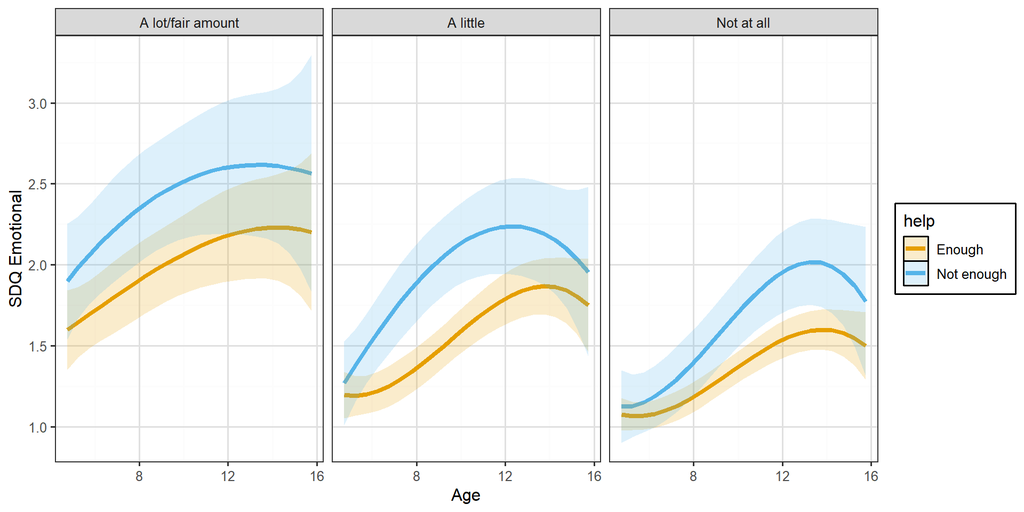

### Covariates sex and income

**Estimates**

[1] “No singular fit” [1] “No convergence issues”

| REML |
| --- |
| 45177.54 |

|  | Dsdem1 |  |  |  |  |  |  |  |  |  |  |
| --- | --- | --- | --- | --- | --- | --- | --- | --- | --- | --- | --- |
| Predictors | Estimates | std. Error | std. Beta | standardized std. Error | CI | standardized CI | Statistic | std. Statistic | p | std. p | df |
| (Intercept) | 1.57 | 0.09 | -0.04 | 0.05 | 1.39 – 1.75 | -0.13 – 0.05 | 17.51 | -0.91 | **<0.001** | 0.362 | 12059.00 |
| food help [A little.Enough] | 0.16 | 0.08 | 0.08 | 0.04 | 0.00 – 0.32 | 0.00 – 0.17 | 2.00 | 1.99 | **0.046** | **0.046** | 12059.00 |
| food help [A little.Not enough] | 0.73 | 0.13 | 0.38 | 0.07 | 0.48 – 0.99 | 0.25 – 0.51 | 5.61 | 5.61 | **<0.001** | **<0.001** | 12059.00 |
| food help [A lot/fair amount.Enough] | 0.57 | 0.13 | 0.30 | 0.07 | 0.32 – 0.83 | 0.16 – 0.43 | 4.39 | 4.39 | **<0.001** | **<0.001** | 12059.00 |
| food help [A lot/fair amount.Not enough] | 1.03 | 0.18 | 0.53 | 0.09 | 0.68 – 1.38 | 0.35 – 0.72 | 5.76 | 5.76 | **<0.001** | **<0.001** | 12059.00 |
| food help [Not at all.Not enough] | 0.30 | 0.11 | 0.15 | 0.06 | 0.08 – 0.52 | 0.04 – 0.27 | 2.62 | 2.62 | **0.009** | **0.009** | 12059.00 |
| age cent | 0.10 | 0.01 | 0.17 | 0.03 | 0.07 – 0.12 | 0.12 – 0.22 | 6.73 | 6.73 | **<0.001** | **<0.001** | 12059.00 |
| age cent^2 | 0.00 | 0.00 | 0.01 | 0.01 | -0.00 – 0.01 | -0.01 – 0.04 | 0.97 | 0.99 | 0.330 | 0.320 | 12059.00 |
| age cent^3 | -0.00 | 0.00 | -0.04 | 0.01 | -0.00 – -0.00 | -0.07 – -0.01 | -2.80 | -2.80 | **0.005** | **0.005** | 12059.00 |
| Sex [F] | 0.09 | 0.05 | 0.05 | 0.03 | -0.02 – 0.20 | -0.01 – 0.10 | 1.67 | 1.67 | 0.095 | 0.095 | 12059.00 |
| DeEqv5 [2] | -0.15 | 0.09 | -0.08 | 0.05 | -0.33 – 0.04 | -0.17 – 0.02 | -1.57 | -1.57 | 0.116 | 0.116 | 12059.00 |
| DeEqv5 [3] | -0.32 | 0.10 | -0.17 | 0.05 | -0.51 – -0.13 | -0.26 – -0.07 | -3.37 | -3.37 | **0.001** | **0.001** | 12059.00 |
| DeEqv5 [4] | -0.48 | 0.09 | -0.25 | 0.05 | -0.66 – -0.30 | -0.34 – -0.15 | -5.21 | -5.21 | **<0.001** | **<0.001** | 12059.00 |
| DeEqv5 [5] | -0.40 | 0.10 | -0.21 | 0.05 | -0.60 – -0.21 | -0.31 – -0.11 | -4.08 | -4.08 | **<0.001** | **<0.001** | 12059.00 |
| food help [A little.Enough] × age cent | 0.02 | 0.02 | 0.04 | 0.04 | -0.03 – 0.07 | -0.05 – 0.13 | 0.90 | 0.90 | 0.368 | 0.367 | 12059.00 |
| food help [A little.Not enough] × age cent | 0.02 | 0.04 | 0.03 | 0.07 | -0.06 – 0.10 | -0.10 – 0.17 | 0.47 | 0.48 | 0.635 | 0.629 | 12059.00 |
| food help [A lot/fair amount.Enough] × age cent | -0.02 | 0.04 | -0.03 | 0.06 | -0.09 – 0.05 | -0.16 – 0.10 | -0.46 | -0.46 | 0.645 | 0.647 | 12059.00 |
| food help [A lot/fair amount.Not enough] × age cent | -0.02 | 0.05 | -0.03 | 0.09 | -0.12 – 0.08 | -0.21 – 0.15 | -0.35 | -0.35 | 0.727 | 0.730 | 12059.00 |
| food help [Not at all.Not enough] × age cent | 0.06 | 0.03 | 0.11 | 0.06 | -0.01 – 0.13 | -0.01 – 0.23 | 1.78 | 1.79 | 0.075 | 0.074 | 12059.00 |
| food help [A little.Enough] × age cent^2 | -0.00 | 0.00 | -0.00 | 0.02 | -0.01 – 0.01 | -0.04 – 0.04 | -0.17 | -0.16 | 0.867 | 0.869 | 12059.00 |
| food help [A little.Not enough] × age cent^2 | -0.02 | 0.01 | -0.11 | 0.03 | -0.03 – -0.01 | -0.18 – -0.05 | -3.38 | -3.37 | **0.001** | **0.001** | 12059.00 |
| food help [A lot/fair amount.Enough] × age cent^2 | -0.01 | 0.00 | -0.04 | 0.03 | -0.02 – 0.00 | -0.10 – 0.02 | -1.39 | -1.39 | 0.165 | 0.164 | 12059.00 |
| food help [A lot/fair amount.Not enough] × age cent^2 | -0.01 | 0.01 | -0.08 | 0.04 | -0.02 – 0.00 | -0.16 – 0.00 | -1.85 | -1.84 | 0.065 | 0.065 | 12059.00 |
| food help [Not at all.Not enough] × age cent^2 | -0.00 | 0.00 | -0.02 | 0.03 | -0.01 – 0.01 | -0.08 – 0.04 | -0.66 | -0.65 | 0.508 | 0.514 | 12059.00 |
| food help [A little.Enough] × age cent^3 | -0.00 | 0.00 | -0.01 | 0.02 | -0.00 – 0.00 | -0.05 – 0.04 | -0.24 | -0.24 | 0.813 | 0.813 | 12059.00 |
| food help [A little.Not enough] × age cent^3 | 0.00 | 0.00 | 0.03 | 0.04 | -0.00 – 0.00 | -0.05 – 0.10 | 0.70 | 0.70 | 0.484 | 0.484 | 12059.00 |
| food help [A lot/fair amount.Enough] × age cent^3 | 0.00 | 0.00 | 0.03 | 0.03 | -0.00 – 0.00 | -0.04 – 0.10 | 0.88 | 0.88 | 0.377 | 0.377 | 12059.00 |
| food help [A lot/fair amount.Not enough] × age cent^3 | 0.00 | 0.00 | 0.04 | 0.05 | -0.00 – 0.01 | -0.06 – 0.14 | 0.85 | 0.85 | 0.396 | 0.396 | 12059.00 |
| food help [Not at all.Not enough] × age cent^3 | -0.00 | 0.00 | -0.02 | 0.03 | -0.00 – 0.00 | -0.09 – 0.05 | -0.66 | -0.66 | 0.507 | 0.507 | 12059.00 |
| Random Effects |  |  |  |  |  |  |  |  |  |  |  |
| σ<sup>2</sup> | 1.37 |  |  |  |  |  |  |  |  |  |  |
| τ<sub>00</sub> <sub>Idnumber</sub> | 1.45 |  |  |  |  |  |  |  |  |  |  |
| τ<sub>11</sub> <sub>Idnumber.age.cent</sub> | 0.03 |  |  |  |  |  |  |  |  |  |  |
| ρ<sub>01</sub> <sub>Idnumber</sub> | 0.47 |  |  |  |  |  |  |  |  |  |  |
| ICC | 0.57 |  |  |  |  |  |  |  |  |  |  |
| N <sub>Idnumber</sub> | 2041 |  |  |  |  |  |  |  |  |  |  |
| Observations | 12092 |  |  |  |  |  |  |  |  |  |  |
| Marginal R<sup>2</sup> / Conditional R<sup>2</sup> | 0.049 / 0.587 |  |  |  |  |  |  |  |  |  |  |

**Lowest income plot**

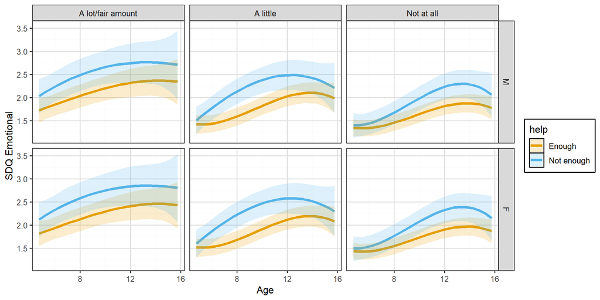

**Highest income plot**

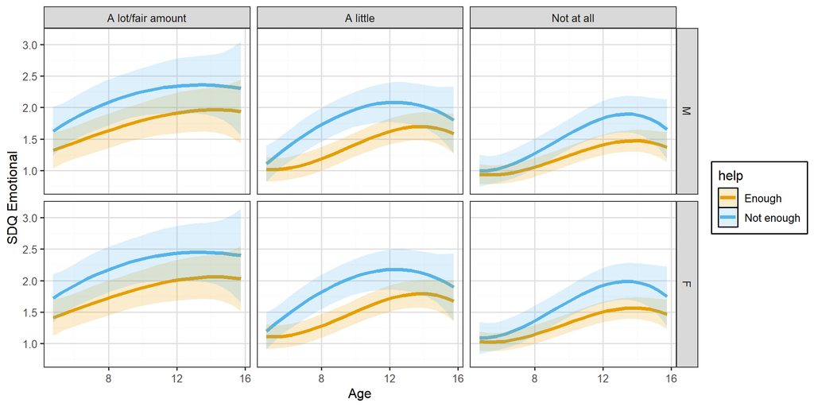

### Sex, income, maternal MH

**Estimates**

[1] “No singular fit” [1] “No convergence issues”

| REML |
| --- |
| 44939.68 |

|  | Dsdem1 |  |  |  |  |  |  |  |  |  |  |
| --- | --- | --- | --- | --- | --- | --- | --- | --- | --- | --- | --- |
| Predictors | Estimates | std. Error | std. Beta | standardized std. Error | CI | standardized CI | Statistic | std. Statistic | p | std. p | df |
| (Intercept) | 1.51 | 0.09 | -0.07 | 0.05 | 1.34 – 1.68 | -0.16 – 0.02 | 17.29 | -1.55 | **<0.001** | 0.122 | 12028.00 |
| food help [A little.Enough] | 0.13 | 0.08 | 0.07 | 0.04 | -0.03 – 0.29 | -0.02 – 0.15 | 1.59 | 1.59 | 0.111 | 0.112 | 12028.00 |
| food help [A little.Not enough] | 0.54 | 0.13 | 0.28 | 0.07 | 0.29 – 0.80 | 0.15 – 0.41 | 4.22 | 4.22 | **<0.001** | **<0.001** | 12028.00 |
| food help [A lot/fair amount.Enough] | 0.43 | 0.13 | 0.22 | 0.07 | 0.18 – 0.68 | 0.09 – 0.35 | 3.38 | 3.39 | **0.001** | **0.001** | 12028.00 |
| food help [A lot/fair amount.Not enough] | 0.75 | 0.18 | 0.39 | 0.09 | 0.41 – 1.10 | 0.21 – 0.57 | 4.26 | 4.26 | **<0.001** | **<0.001** | 12028.00 |
| food help [Not at all.Not enough] | 0.23 | 0.11 | 0.12 | 0.06 | 0.01 – 0.45 | 0.01 – 0.23 | 2.08 | 2.07 | **0.038** | **0.038** | 12028.00 |
| age cent | 0.10 | 0.01 | 0.17 | 0.03 | 0.07 – 0.12 | 0.12 – 0.23 | 6.75 | 6.75 | **<0.001** | **<0.001** | 12028.00 |
| age cent^2 | 0.00 | 0.00 | 0.01 | 0.01 | -0.00 – 0.01 | -0.01 – 0.04 | 1.01 | 1.04 | 0.311 | 0.297 | 12028.00 |
| age cent^3 | -0.00 | 0.00 | -0.04 | 0.01 | -0.00 – -0.00 | -0.07 – -0.01 | -2.80 | -2.80 | **0.005** | **0.005** | 12028.00 |
| Sex [F] | 0.11 | 0.05 | 0.06 | 0.03 | 0.01 – 0.22 | 0.00 – 0.11 | 2.08 | 2.08 | **0.038** | **0.038** | 12028.00 |
| DeEqv5 [2] | -0.09 | 0.09 | -0.04 | 0.05 | -0.26 – 0.09 | -0.14 – 0.05 | -0.95 | -0.95 | 0.344 | 0.344 | 12028.00 |
| DeEqv5 [3] | -0.21 | 0.09 | -0.11 | 0.05 | -0.39 – -0.03 | -0.20 – -0.02 | -2.27 | -2.27 | **0.023** | **0.023** | 12028.00 |
| DeEqv5 [4] | -0.36 | 0.09 | -0.19 | 0.05 | -0.54 – -0.18 | -0.28 – -0.10 | -4.01 | -4.01 | **<0.001** | **<0.001** | 12028.00 |
| DeEqv5 [5] | -0.26 | 0.10 | -0.14 | 0.05 | -0.45 – -0.07 | -0.23 – -0.04 | -2.70 | -2.70 | **0.007** | **0.007** | 12028.00 |
| DeSf12mn | -0.28 | 0.03 | -0.15 | 0.01 | -0.34 – -0.23 | -0.18 – -0.12 | -10.34 | -10.34 | **<0.001** | **<0.001** | 12028.00 |
| food help [A little.Enough] × age cent | 0.02 | 0.02 | 0.04 | 0.04 | -0.03 – 0.07 | -0.05 – 0.12 | 0.83 | 0.83 | 0.407 | 0.406 | 12028.00 |
| food help [A little.Not enough] × age cent | 0.02 | 0.04 | 0.04 | 0.07 | -0.06 – 0.10 | -0.10 – 0.17 | 0.51 | 0.52 | 0.612 | 0.603 | 12028.00 |
| food help [A lot/fair amount.Enough] × age cent | -0.01 | 0.04 | -0.01 | 0.07 | -0.08 – 0.06 | -0.14 – 0.12 | -0.19 | -0.19 | 0.847 | 0.849 | 12028.00 |
| food help [A lot/fair amount.Not enough] × age cent | -0.02 | 0.05 | -0.03 | 0.09 | -0.12 – 0.08 | -0.21 – 0.15 | -0.34 | -0.34 | 0.732 | 0.737 | 12028.00 |
| food help [Not at all.Not enough] × age cent | 0.06 | 0.03 | 0.11 | 0.06 | -0.01 – 0.13 | -0.01 – 0.23 | 1.76 | 1.76 | 0.079 | 0.078 | 12028.00 |
| food help [A little.Enough] × age cent^2 | -0.00 | 0.00 | -0.00 | 0.02 | -0.01 – 0.01 | -0.05 – 0.04 | -0.18 | -0.18 | 0.856 | 0.859 | 12028.00 |
| food help [A little.Not enough] × age cent^2 | -0.02 | 0.01 | -0.11 | 0.03 | -0.03 – -0.01 | -0.18 – -0.05 | -3.39 | -3.38 | **0.001** | **0.001** | 12028.00 |
| food help [A lot/fair amount.Enough] × age cent^2 | -0.00 | 0.00 | -0.03 | 0.03 | -0.01 – 0.00 | -0.09 – 0.03 | -0.98 | -0.98 | 0.327 | 0.326 | 12028.00 |
| food help [A lot/fair amount.Not enough] × age cent^2 | -0.01 | 0.01 | -0.08 | 0.04 | -0.02 – 0.00 | -0.16 – 0.00 | -1.86 | -1.86 | 0.063 | 0.063 | 12028.00 |
| food help [Not at all.Not enough] × age cent^2 | -0.00 | 0.00 | -0.02 | 0.03 | -0.01 – 0.01 | -0.08 – 0.04 | -0.69 | -0.67 | 0.493 | 0.501 | 12028.00 |
| food help [A little.Enough] × age cent^3 | -0.00 | 0.00 | -0.00 | 0.02 | -0.00 – 0.00 | -0.05 – 0.04 | -0.20 | -0.20 | 0.842 | 0.842 | 12028.00 |
| food help [A little.Not enough] × age cent^3 | 0.00 | 0.00 | 0.03 | 0.04 | -0.00 – 0.00 | -0.05 – 0.10 | 0.69 | 0.69 | 0.490 | 0.490 | 12028.00 |
| food help [A lot/fair amount.Enough] × age cent^3 | 0.00 | 0.00 | 0.02 | 0.04 | -0.00 – 0.00 | -0.05 – 0.09 | 0.67 | 0.67 | 0.501 | 0.501 | 12028.00 |
| food help [A lot/fair amount.Not enough] × age cent^3 | 0.00 | 0.00 | 0.04 | 0.05 | -0.00 – 0.01 | -0.06 – 0.14 | 0.85 | 0.85 | 0.398 | 0.398 | 12028.00 |
| food help [Not at all.Not enough] × age cent^3 | -0.00 | 0.00 | -0.02 | 0.03 | -0.00 – 0.00 | -0.09 – 0.05 | -0.66 | -0.66 | 0.507 | 0.507 | 12028.00 |
| Random Effects |  |  |  |  |  |  |  |  |  |  |  |
| σ<sup>2</sup> | 1.37 |  |  |  |  |  |  |  |  |  |  |
| τ<sub>00</sub> <sub>Idnumber</sub> | 1.35 |  |  |  |  |  |  |  |  |  |  |
| τ<sub>11</sub> <sub>Idnumber.age.cent</sub> | 0.03 |  |  |  |  |  |  |  |  |  |  |
| ρ<sub>01</sub> <sub>Idnumber</sub> | 0.48 |  |  |  |  |  |  |  |  |  |  |
| ICC | 0.55 |  |  |  |  |  |  |  |  |  |  |
| N <sub>Idnumber</sub> | 2035 |  |  |  |  |  |  |  |  |  |  |
| Observations | 12062 |  |  |  |  |  |  |  |  |  |  |
| Marginal R<sup>2</sup> / Conditional R<sup>2</sup> | 0.071 / 0.584 |  |  |  |  |  |  |  |  |  |  |

**Lowest income plot**

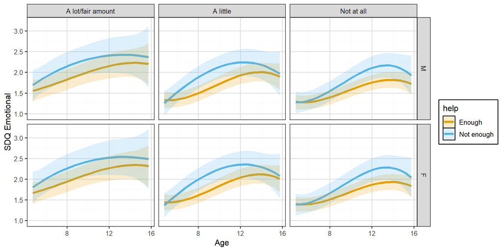

**Highest income plot**

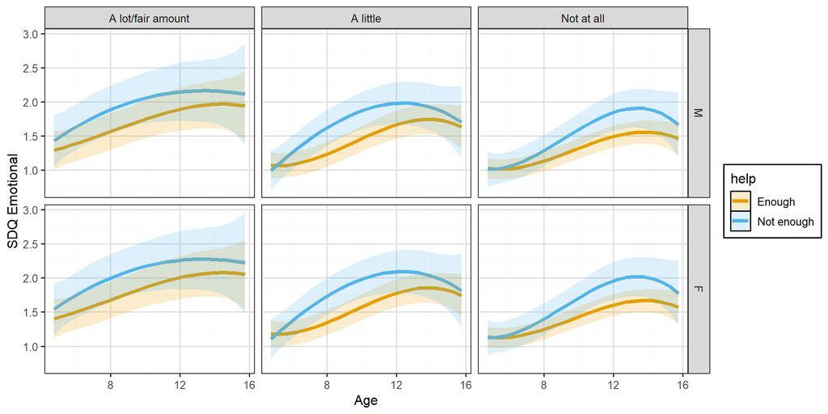

### Sex, income, maternal MH, SIMD

**Estimates**

[1] “No singular fit” [1] “No convergence issues”

| REML |
| --- |
| 44947.01 |

|  | Dsdem1 |  |  |  |  |  |  |  |  |  |  |
| --- | --- | --- | --- | --- | --- | --- | --- | --- | --- | --- | --- |
| Predictors | Estimates | std. Error | std. Beta | standardized std. Error | CI | standardized CI | Statistic | std. Statistic | p | std. p | df |
| (Intercept) | 1.39 | 0.11 | -0.13 | 0.06 | 1.18 – 1.60 | -0.24 – -0.02 | 12.92 | -2.37 | **<0.001** | **0.018** | 12024.00 |
| food help [A little.Enough] | 0.13 | 0.08 | 0.07 | 0.04 | -0.02 – 0.29 | -0.01 – 0.15 | 1.65 | 1.65 | 0.099 | 0.099 | 12024.00 |
| food help [A little.Not enough] | 0.55 | 0.13 | 0.28 | 0.07 | 0.29 – 0.80 | 0.15 – 0.41 | 4.23 | 4.23 | **<0.001** | **<0.001** | 12024.00 |
| food help [A lot/fair amount.Enough] | 0.42 | 0.13 | 0.22 | 0.07 | 0.17 – 0.67 | 0.09 – 0.35 | 3.30 | 3.30 | **0.001** | **0.001** | 12024.00 |
| food help [A lot/fair amount.Not enough] | 0.75 | 0.18 | 0.39 | 0.09 | 0.40 – 1.09 | 0.21 – 0.57 | 4.21 | 4.22 | **<0.001** | **<0.001** | 12024.00 |
| food help [Not at all.Not enough] | 0.24 | 0.11 | 0.12 | 0.06 | 0.02 – 0.46 | 0.01 – 0.24 | 2.13 | 2.12 | **0.033** | **0.034** | 12024.00 |
| age cent | 0.10 | 0.01 | 0.18 | 0.03 | 0.07 – 0.13 | 0.12 – 0.23 | 6.76 | 6.77 | **<0.001** | **<0.001** | 12024.00 |
| age cent^2 | 0.00 | 0.00 | 0.01 | 0.01 | -0.00 – 0.01 | -0.01 – 0.04 | 1.01 | 1.04 | 0.310 | 0.296 | 12024.00 |
| age cent^3 | -0.00 | 0.00 | -0.04 | 0.01 | -0.00 – -0.00 | -0.07 – -0.01 | -2.80 | -2.80 | **0.005** | **0.005** | 12024.00 |
| Sex [F] | 0.11 | 0.05 | 0.06 | 0.03 | 0.01 – 0.21 | 0.00 – 0.11 | 2.05 | 2.05 | **0.040** | **0.040** | 12024.00 |
| DeEqv5 [2] | -0.07 | 0.09 | -0.04 | 0.05 | -0.25 – 0.11 | -0.13 – 0.06 | -0.75 | -0.75 | 0.452 | 0.452 | 12024.00 |
| DeEqv5 [3] | -0.18 | 0.09 | -0.09 | 0.05 | -0.36 – 0.01 | -0.19 – 0.01 | -1.86 | -1.86 | 0.063 | 0.063 | 12024.00 |
| DeEqv5 [4] | -0.30 | 0.09 | -0.16 | 0.05 | -0.48 – -0.12 | -0.25 – -0.06 | -3.20 | -3.20 | **0.001** | **0.001** | 12024.00 |
| DeEqv5 [5] | -0.18 | 0.10 | -0.10 | 0.05 | -0.38 – 0.02 | -0.20 – 0.01 | -1.80 | -1.80 | 0.073 | 0.073 | 12024.00 |
| DeSf12mn | -0.28 | 0.03 | -0.15 | 0.01 | -0.34 – -0.23 | -0.17 – -0.12 | -10.25 | -10.25 | **<0.001** | **<0.001** | 12024.00 |
| ALeSNim2 [2] | 0.07 | 0.08 | 0.03 | 0.04 | -0.09 – 0.22 | -0.04 – 0.11 | 0.86 | 0.86 | 0.391 | 0.391 | 12024.00 |
| ALeSNim2 [3] | 0.05 | 0.08 | 0.02 | 0.04 | -0.11 – 0.21 | -0.06 – 0.11 | 0.57 | 0.57 | 0.568 | 0.568 | 12024.00 |
| ALeSNim2 [4] | 0.15 | 0.09 | 0.08 | 0.05 | -0.02 – 0.33 | -0.01 – 0.17 | 1.72 | 1.72 | 0.085 | 0.085 | 12024.00 |
| ALeSNim2 [5] | 0.21 | 0.10 | 0.11 | 0.05 | 0.02 – 0.40 | 0.01 – 0.21 | 2.14 | 2.14 | **0.033** | **0.033** | 12024.00 |
| food help [A little.Enough] × age cent | 0.02 | 0.02 | 0.04 | 0.04 | -0.03 – 0.07 | -0.05 – 0.12 | 0.83 | 0.83 | 0.406 | 0.405 | 12024.00 |
| food help [A little.Not enough] × age cent | 0.02 | 0.04 | 0.04 | 0.07 | -0.06 – 0.10 | -0.10 – 0.17 | 0.51 | 0.52 | 0.610 | 0.601 | 12024.00 |
| food help [A lot/fair amount.Enough] × age cent | -0.01 | 0.04 | -0.01 | 0.07 | -0.08 – 0.06 | -0.14 – 0.12 | -0.19 | -0.19 | 0.851 | 0.853 | 12024.00 |
| food help [A lot/fair amount.Not enough] × age cent | -0.02 | 0.05 | -0.03 | 0.09 | -0.12 – 0.08 | -0.21 – 0.15 | -0.34 | -0.33 | 0.735 | 0.739 | 12024.00 |
| food help [Not at all.Not enough] × age cent | 0.06 | 0.03 | 0.11 | 0.06 | -0.01 – 0.13 | -0.01 – 0.23 | 1.76 | 1.77 | 0.078 | 0.077 | 12024.00 |
| food help [A little.Enough] × age cent^2 | -0.00 | 0.00 | -0.00 | 0.02 | -0.01 – 0.01 | -0.05 – 0.04 | -0.18 | -0.18 | 0.855 | 0.858 | 12024.00 |
| food help [A little.Not enough] × age cent^2 | -0.02 | 0.01 | -0.11 | 0.03 | -0.03 – -0.01 | -0.18 – -0.05 | -3.40 | -3.38 | **0.001** | **0.001** | 12024.00 |
| food help [A lot/fair amount.Enough] × age cent^2 | -0.00 | 0.00 | -0.03 | 0.03 | -0.01 – 0.00 | -0.09 – 0.03 | -0.98 | -0.98 | 0.326 | 0.325 | 12024.00 |
| food help [A lot/fair amount.Not enough] × age cent^2 | -0.01 | 0.01 | -0.08 | 0.04 | -0.02 – 0.00 | -0.16 – 0.00 | -1.86 | -1.86 | 0.063 | 0.063 | 12024.00 |
| food help [Not at all.Not enough] × age cent^2 | -0.00 | 0.00 | -0.02 | 0.03 | -0.01 – 0.01 | -0.08 – 0.04 | -0.68 | -0.67 | 0.495 | 0.503 | 12024.00 |
| food help [A little.Enough] × age cent^3 | -0.00 | 0.00 | -0.00 | 0.02 | -0.00 – 0.00 | -0.05 – 0.04 | -0.20 | -0.20 | 0.842 | 0.842 | 12024.00 |
| food help [A little.Not enough] × age cent^3 | 0.00 | 0.00 | 0.03 | 0.04 | -0.00 – 0.00 | -0.05 – 0.10 | 0.69 | 0.69 | 0.490 | 0.490 | 12024.00 |
| food help [A lot/fair amount.Enough] × age cent^3 | 0.00 | 0.00 | 0.02 | 0.04 | -0.00 – 0.00 | -0.05 – 0.09 | 0.67 | 0.67 | 0.500 | 0.500 | 12024.00 |
| food help [A lot/fair amount.Not enough] × age cent^3 | 0.00 | 0.00 | 0.04 | 0.05 | -0.00 – 0.01 | -0.06 – 0.14 | 0.85 | 0.85 | 0.397 | 0.397 | 12024.00 |
| food help [Not at all.Not enough] × age cent^3 | -0.00 | 0.00 | -0.02 | 0.03 | -0.00 – 0.00 | -0.09 – 0.05 | -0.66 | -0.66 | 0.507 | 0.507 | 12024.00 |
| Random Effects |  |  |  |  |  |  |  |  |  |  |  |
| σ<sup>2</sup> | 1.37 |  |  |  |  |  |  |  |  |  |  |
| τ<sub>00</sub> <sub>Idnumber</sub> | 1.35 |  |  |  |  |  |  |  |  |  |  |
| τ<sub>11</sub> <sub>Idnumber.age.cent</sub> | 0.03 |  |  |  |  |  |  |  |  |  |  |
| ρ<sub>01</sub> <sub>Idnumber</sub> | 0.48 |  |  |  |  |  |  |  |  |  |  |
| ICC | 0.55 |  |  |  |  |  |  |  |  |  |  |
| N <sub>Idnumber</sub> | 2035 |  |  |  |  |  |  |  |  |  |  |
| Observations | 12062 |  |  |  |  |  |  |  |  |  |  |
| Marginal R<sup>2</sup> / Conditional R<sup>2</sup> | 0.072 / 0.584 |  |  |  |  |  |  |  |  |  |  |

**Contrasts**

| Age | contrast | null.value | estimate | std.error | df | statistic | p.value |
| --- | --- | --- | --- | --- | --- | --- | --- |
| 5 | Not at all.Not enough vs Enough | 0 | 0.001 | 0.112 | 3121.244 | 0.007 | 0.994 |
| 5 | A little.Not enough vs Enough | 0 | -0.019 | 0.136 | 2987.926 | -0.142 | 0.887 |
| 5 | A lot/fair amount.Not enough vs Enough | 0 | 0.167 | 0.201 | 2413.761 | 0.828 | 0.408 |
| 6 | Not at all.Not enough vs Enough | 0 | 0.041 | 0.102 | 2640.700 | 0.403 | 0.687 |
| 6 | A little.Not enough vs Enough | 0 | 0.175 | 0.124 | 2541.232 | 1.416 | 0.157 |
| 6 | A lot/fair amount.Not enough vs Enough | 0 | 0.248 | 0.185 | 2169.010 | 1.338 | 0.181 |
| 7 | Not at all.Not enough vs Enough | 0 | 0.095 | 0.109 | 3757.757 | 0.875 | 0.382 |
| 7 | A little.Not enough vs Enough | 0 | 0.306 | 0.132 | 3581.854 | 2.314 | 0.021 |
| 7 | A lot/fair amount.Not enough vs Enough | 0 | 0.298 | 0.196 | 3005.565 | 1.518 | 0.129 |
| 8 | Not at all.Not enough vs Enough | 0 | 0.158 | 0.112 | 3981.850 | 1.413 | 0.158 |
| 8 | A little.Not enough vs Enough | 0 | 0.382 | 0.135 | 3805.319 | 2.823 | 0.005 |
| 8 | A lot/fair amount.Not enough vs Enough | 0 | 0.322 | 0.201 | 3203.147 | 1.604 | 0.109 |
| 9 | Not at all.Not enough vs Enough | 0 | 0.221 | 0.111 | 3468.692 | 1.989 | 0.047 |
| 9 | A little.Not enough vs Enough | 0 | 0.412 | 0.135 | 3348.767 | 3.040 | 0.002 |
| 9 | A lot/fair amount.Not enough vs Enough | 0 | 0.325 | 0.202 | 2865.291 | 1.607 | 0.108 |
| 10 | Not at all.Not enough vs Enough | 0 | 0.281 | 0.116 | 3151.385 | 2.427 | 0.015 |
| 10 | A little.Not enough vs Enough | 0 | 0.404 | 0.141 | 3070.570 | 2.871 | 0.004 |
| 10 | A lot/fair amount.Not enough vs Enough | 0 | 0.312 | 0.211 | 2661.719 | 1.476 | 0.140 |
| 11 | Not at all.Not enough vs Enough | 0 | 0.328 | 0.126 | 3191.044 | 2.614 | 0.009 |
| 11 | A little.Not enough vs Enough | 0 | 0.367 | 0.153 | 3117.374 | 2.403 | 0.016 |
| 11 | A lot/fair amount.Not enough vs Enough | 0 | 0.288 | 0.230 | 2699.518 | 1.252 | 0.211 |
| 12 | Not at all.Not enough vs Enough | 0 | 0.359 | 0.136 | 3117.469 | 2.632 | 0.009 |
| 12 | A little.Not enough vs Enough | 0 | 0.311 | 0.166 | 3048.022 | 1.873 | 0.061 |
| 12 | A lot/fair amount.Not enough vs Enough | 0 | 0.257 | 0.249 | 2639.817 | 1.031 | 0.303 |
| 13 | Not at all.Not enough vs Enough | 0 | 0.366 | 0.143 | 2655.852 | 2.557 | 0.011 |
| 13 | A little.Not enough vs Enough | 0 | 0.242 | 0.174 | 2598.096 | 1.393 | 0.164 |
| 13 | A lot/fair amount.Not enough vs Enough | 0 | 0.226 | 0.263 | 2290.815 | 0.856 | 0.392 |
| 14 | Not at all.Not enough vs Enough | 0 | 0.343 | 0.152 | 2333.924 | 2.261 | 0.024 |
| 14 | A little.Not enough vs Enough | 0 | 0.171 | 0.183 | 2253.100 | 0.933 | 0.351 |
| 14 | A lot/fair amount.Not enough vs Enough | 0 | 0.198 | 0.280 | 2042.010 | 0.706 | 0.480 |
| 15 | Not at all.Not enough vs Enough | 0 | 0.283 | 0.189 | 3688.517 | 1.501 | 0.133 |
| 15 | A little.Not enough vs Enough | 0 | 0.106 | 0.225 | 3434.370 | 0.470 | 0.639 |
| 15 | A lot/fair amount.Not enough vs Enough | 0 | 0.179 | 0.339 | 3017.595 | 0.527 | 0.599 |
| 16 | Not at all.Not enough vs Enough | 0 | 0.181 | 0.287 | 8304.744 | 0.630 | 0.529 |
| 16 | A little.Not enough vs Enough | 0 | 0.055 | 0.339 | 7941.341 | 0.162 | 0.872 |
| 16 | A lot/fair amount.Not enough vs Enough | 0 | 0.173 | 0.495 | 7101.596 | 0.350 | 0.726 |

**Lowest income plot**

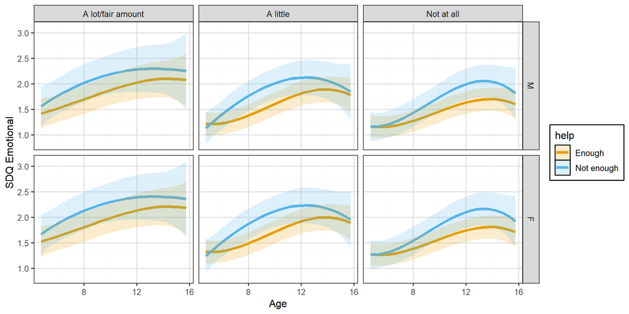

**Highest income plot**

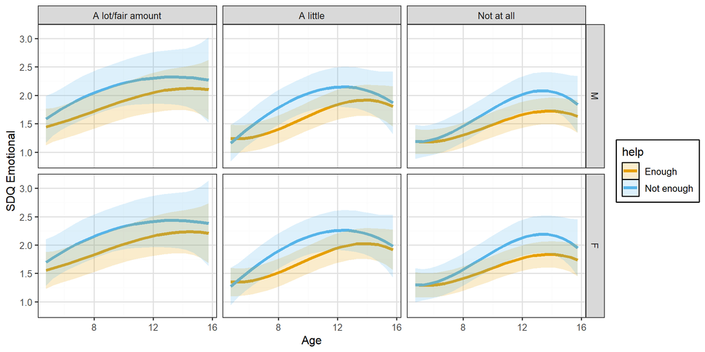

## Hyperactivity

### No covariates

**Estimates**

[1] “No singular fit” [1] “No convergence issues”

| REML |
| --- |
| 48412.72 |

|  | Dsdhy1 |  |  |  |  |  |  |  |  |  |  |
| --- | --- | --- | --- | --- | --- | --- | --- | --- | --- | --- | --- |
| Predictors | Estimates | std. Error | std. Beta | standardized std. Error | CI | standardized CI | Statistic | std. Statistic | p | std. p | df |
| (Intercept) | 2.82 | 0.06 | -0.20 | 0.02 | 2.70 – 2.94 | -0.25 – -0.15 | 45.45 | -7.98 | **<0.001** | **<0.001** | 12076.00 |
| food help [A little.Enough] | 0.25 | 0.11 | 0.10 | 0.04 | 0.04 – 0.46 | 0.02 – 0.19 | 2.33 | 2.33 | **0.020** | **0.020** | 12076.00 |
| food help [A little.Not enough] | 0.54 | 0.17 | 0.22 | 0.07 | 0.20 – 0.88 | 0.08 – 0.35 | 3.14 | 3.14 | **0.002** | **0.002** | 12076.00 |
| food help [A lot/fair amount.Enough] | 0.88 | 0.17 | 0.36 | 0.07 | 0.55 – 1.22 | 0.22 – 0.49 | 5.11 | 5.11 | **<0.001** | **<0.001** | 12076.00 |
| food help [A lot/fair amount.Not enough] | 1.38 | 0.24 | 0.56 | 0.10 | 0.91 – 1.86 | 0.37 – 0.75 | 5.70 | 5.71 | **<0.001** | **<0.001** | 12076.00 |
| food help [Not at all.Not enough] | 0.31 | 0.15 | 0.12 | 0.06 | 0.01 – 0.60 | 0.01 – 0.24 | 2.04 | 2.04 | **0.041** | **0.041** | 12076.00 |
| age cent | -0.09 | 0.01 | -0.12 | 0.01 | -0.10 – -0.07 | -0.14 – -0.10 | -11.22 | -11.22 | **<0.001** | **<0.001** | 12076.00 |
| food help [A little.Enough] × age cent | -0.01 | 0.01 | -0.01 | 0.02 | -0.03 – 0.02 | -0.05 – 0.03 | -0.58 | -0.58 | 0.562 | 0.562 | 12076.00 |
| food help [A little.Not enough] × age cent | -0.02 | 0.02 | -0.03 | 0.03 | -0.06 – 0.02 | -0.08 – 0.03 | -0.86 | -0.86 | 0.389 | 0.389 | 12076.00 |
| food help [A lot/fair amount.Enough] × age cent | 0.01 | 0.02 | 0.01 | 0.03 | -0.03 – 0.05 | -0.05 – 0.07 | 0.36 | 0.36 | 0.719 | 0.719 | 12076.00 |
| food help [A lot/fair amount.Not enough] × age cent | -0.04 | 0.03 | -0.06 | 0.04 | -0.10 – 0.02 | -0.14 – 0.02 | -1.38 | -1.38 | 0.169 | 0.169 | 12076.00 |
| food help [Not at all.Not enough] × age cent | 0.01 | 0.02 | 0.01 | 0.03 | -0.03 – 0.05 | -0.04 – 0.06 | 0.47 | 0.47 | 0.635 | 0.635 | 12076.00 |
| Random Effects |  |  |  |  |  |  |  |  |  |  |  |
| σ<sup>2</sup> | 1.60 |  |  |  |  |  |  |  |  |  |  |
| τ<sub>00</sub> <sub>Idnumber</sub> | 3.48 |  |  |  |  |  |  |  |  |  |  |
| τ<sub>11</sub> <sub>Idnumber.age.cent</sub> | 0.03 |  |  |  |  |  |  |  |  |  |  |
| ρ<sub>01</sub> <sub>Idnumber</sub> | 0.05 |  |  |  |  |  |  |  |  |  |  |
| ICC | 0.71 |  |  |  |  |  |  |  |  |  |  |
| N <sub>Idnumber</sub> | 2041 |  |  |  |  |  |  |  |  |  |  |
| Observations | 12092 |  |  |  |  |  |  |  |  |  |  |
| Marginal R<sup>2</sup> / Conditional R<sup>2</sup> | 0.037 / 0.719 |  |  |  |  |  |  |  |  |  |  |

**Contrasts**

| Age | contrast | null.value | estimate | std.error | df | statistic | p.value |
| --- | --- | --- | --- | --- | --- | --- | --- |
| 5 | Not at all.Not enough vs Enough | 0 | 0.269 | 0.168 | 2102.770 | 1.601 | 0.110 |
| 5 | A little.Not enough vs Enough | 0 | 0.335 | 0.205 | 2060.613 | 1.636 | 0.102 |
| 5 | A lot/fair amount.Not enough vs Enough | 0 | 0.704 | 0.315 | 1936.531 | 2.235 | 0.026 |
| 6 | Not at all.Not enough vs Enough | 0 | 0.278 | 0.161 | 2089.187 | 1.732 | 0.083 |
| 6 | A little.Not enough vs Enough | 0 | 0.324 | 0.196 | 2055.964 | 1.657 | 0.098 |
| 6 | A lot/fair amount.Not enough vs Enough | 0 | 0.657 | 0.302 | 1954.474 | 2.174 | 0.030 |
| 7 | Not at all.Not enough vs Enough | 0 | 0.287 | 0.155 | 2078.684 | 1.853 | 0.064 |
| 7 | A little.Not enough vs Enough | 0 | 0.314 | 0.189 | 2052.464 | 1.660 | 0.097 |
| 7 | A lot/fair amount.Not enough vs Enough | 0 | 0.609 | 0.292 | 1970.584 | 2.083 | 0.037 |
| 8 | Not at all.Not enough vs Enough | 0 | 0.296 | 0.152 | 2072.067 | 1.955 | 0.051 |
| 8 | A little.Not enough vs Enough | 0 | 0.303 | 0.185 | 2049.835 | 1.639 | 0.101 |
| 8 | A lot/fair amount.Not enough vs Enough | 0 | 0.561 | 0.286 | 1982.229 | 1.959 | 0.050 |
| 9 | Not at all.Not enough vs Enough | 0 | 0.306 | 0.151 | 2070.177 | 2.030 | 0.043 |
| 9 | A little.Not enough vs Enough | 0 | 0.292 | 0.183 | 2048.173 | 1.593 | 0.111 |
| 9 | A lot/fair amount.Not enough vs Enough | 0 | 0.514 | 0.285 | 1987.535 | 1.805 | 0.071 |
| 10 | Not at all.Not enough vs Enough | 0 | 0.315 | 0.152 | 2073.838 | 2.072 | 0.038 |
| 10 | A little.Not enough vs Enough | 0 | 0.282 | 0.185 | 2048.205 | 1.523 | 0.128 |
| 10 | A lot/fair amount.Not enough vs Enough | 0 | 0.466 | 0.287 | 1986.323 | 1.625 | 0.104 |
| 11 | Not at all.Not enough vs Enough | 0 | 0.324 | 0.155 | 2083.553 | 2.083 | 0.037 |
| 11 | A little.Not enough vs Enough | 0 | 0.271 | 0.189 | 2051.039 | 1.433 | 0.152 |
| 11 | A lot/fair amount.Not enough vs Enough | 0 | 0.418 | 0.293 | 1980.167 | 1.428 | 0.153 |
| 12 | Not at all.Not enough vs Enough | 0 | 0.333 | 0.161 | 2099.114 | 2.064 | 0.039 |
| 12 | A little.Not enough vs Enough | 0 | 0.260 | 0.196 | 2057.510 | 1.329 | 0.184 |
| 12 | A lot/fair amount.Not enough vs Enough | 0 | 0.371 | 0.303 | 1971.491 | 1.224 | 0.221 |
| 13 | Not at all.Not enough vs Enough | 0 | 0.342 | 0.169 | 2119.480 | 2.024 | 0.043 |
| 13 | A little.Not enough vs Enough | 0 | 0.250 | 0.205 | 2067.695 | 1.218 | 0.223 |
| 13 | A lot/fair amount.Not enough vs Enough | 0 | 0.323 | 0.316 | 1962.475 | 1.022 | 0.307 |
| 14 | Not at all.Not enough vs Enough | 0 | 0.351 | 0.178 | 2143.039 | 1.967 | 0.049 |
| 14 | A little.Not enough vs Enough | 0 | 0.239 | 0.216 | 2080.904 | 1.106 | 0.269 |
| 14 | A lot/fair amount.Not enough vs Enough | 0 | 0.275 | 0.333 | 1954.464 | 0.828 | 0.408 |
| 15 | Not at all.Not enough vs Enough | 0 | 0.360 | 0.189 | 2168.050 | 1.902 | 0.057 |
| 15 | A little.Not enough vs Enough | 0 | 0.228 | 0.229 | 2096.026 | 0.997 | 0.319 |
| 15 | A lot/fair amount.Not enough vs Enough | 0 | 0.228 | 0.351 | 1947.973 | 0.648 | 0.517 |
| 16 | Not at all.Not enough vs Enough | 0 | 0.369 | 0.201 | 2193.014 | 1.833 | 0.067 |
| 16 | A little.Not enough vs Enough | 0 | 0.218 | 0.243 | 2111.916 | 0.895 | 0.371 |
| 16 | A lot/fair amount.Not enough vs Enough | 0 | 0.180 | 0.372 | 1942.981 | 0.484 | 0.629 |

**Plot**

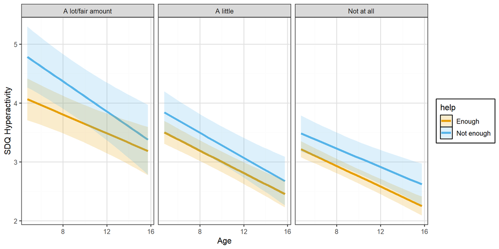

### Covariates sex and income

**Estimates**

[1] “No singular fit” [1] “No convergence issues”

| REML |
| --- |
| 48291.37 |

|  | Dsdhy1 |  |  |  |  |  |  |  |  |  |  |
| --- | --- | --- | --- | --- | --- | --- | --- | --- | --- | --- | --- |
| Predictors | Estimates | std. Error | std. Beta | standardized std. Error | CI | standardized CI | Statistic | std. Statistic | p | std. p | df |
| (Intercept) | 3.94 | 0.13 | 0.25 | 0.05 | 3.68 – 4.20 | 0.15 – 0.36 | 29.56 | 4.71 | **<0.001** | **<0.001** | 12071.00 |
| food help [A little.Enough] | 0.15 | 0.11 | 0.06 | 0.04 | -0.06 – 0.36 | -0.02 – 0.14 | 1.41 | 1.41 | 0.159 | 0.159 | 12071.00 |
| food help [A little.Not enough] | 0.38 | 0.17 | 0.15 | 0.07 | 0.05 – 0.71 | 0.02 – 0.29 | 2.26 | 2.26 | **0.024** | **0.024** | 12071.00 |
| food help [A lot/fair amount.Enough] | 0.52 | 0.17 | 0.21 | 0.07 | 0.18 – 0.86 | 0.07 – 0.34 | 2.99 | 2.99 | **0.003** | **0.003** | 12071.00 |
| food help [A lot/fair amount.Not enough] | 1.08 | 0.24 | 0.43 | 0.10 | 0.61 – 1.55 | 0.25 – 0.62 | 4.53 | 4.54 | **<0.001** | **<0.001** | 12071.00 |
| food help [Not at all.Not enough] | 0.25 | 0.15 | 0.10 | 0.06 | -0.03 – 0.54 | -0.01 – 0.22 | 1.72 | 1.72 | 0.085 | 0.085 | 12071.00 |
| age cent | -0.09 | 0.01 | -0.12 | 0.01 | -0.10 – -0.07 | -0.14 – -0.10 | -11.18 | -11.18 | **<0.001** | **<0.001** | 12071.00 |
| Sex [F] | -0.75 | 0.08 | -0.30 | 0.03 | -0.91 – -0.58 | -0.37 – -0.23 | -8.90 | -8.90 | **<0.001** | **<0.001** | 12071.00 |
| DeEqv5 [2] | -0.47 | 0.14 | -0.19 | 0.06 | -0.76 – -0.19 | -0.30 – -0.08 | -3.28 | -3.28 | **0.001** | **0.001** | 12071.00 |
| DeEqv5 [3] | -0.73 | 0.15 | -0.29 | 0.06 | -1.02 – -0.44 | -0.41 – -0.18 | -4.91 | -4.91 | **<0.001** | **<0.001** | 12071.00 |
| DeEqv5 [4] | -0.94 | 0.14 | -0.38 | 0.06 | -1.22 – -0.67 | -0.49 – -0.27 | -6.67 | -6.67 | **<0.001** | **<0.001** | 12071.00 |
| DeEqv5 [5] | -1.01 | 0.15 | -0.41 | 0.06 | -1.31 – -0.72 | -0.53 – -0.29 | -6.68 | -6.68 | **<0.001** | **<0.001** | 12071.00 |
| food help [A little.Enough] × age cent | -0.01 | 0.01 | -0.01 | 0.02 | -0.03 – 0.02 | -0.05 – 0.03 | -0.59 | -0.59 | 0.557 | 0.557 | 12071.00 |
| food help [A little.Not enough] × age cent | -0.02 | 0.02 | -0.03 | 0.03 | -0.06 – 0.02 | -0.08 – 0.03 | -0.86 | -0.86 | 0.391 | 0.391 | 12071.00 |
| food help [A lot/fair amount.Enough] × age cent | 0.01 | 0.02 | 0.01 | 0.03 | -0.03 – 0.05 | -0.05 – 0.07 | 0.37 | 0.37 | 0.715 | 0.715 | 12071.00 |
| food help [A lot/fair amount.Not enough] × age cent | -0.04 | 0.03 | -0.06 | 0.04 | -0.10 – 0.02 | -0.14 – 0.02 | -1.37 | -1.37 | 0.170 | 0.170 | 12071.00 |
| food help [Not at all.Not enough] × age cent | 0.01 | 0.02 | 0.01 | 0.03 | -0.03 – 0.05 | -0.04 – 0.06 | 0.47 | 0.47 | 0.635 | 0.635 | 12071.00 |
| Random Effects |  |  |  |  |  |  |  |  |  |  |  |
| σ<sup>2</sup> | 1.59 |  |  |  |  |  |  |  |  |  |  |
| τ<sub>00</sub> <sub>Idnumber</sub> | 3.24 |  |  |  |  |  |  |  |  |  |  |
| τ<sub>11</sub> <sub>Idnumber.age.cent</sub> | 0.03 |  |  |  |  |  |  |  |  |  |  |
| ρ<sub>01</sub> <sub>Idnumber</sub> | 0.02 |  |  |  |  |  |  |  |  |  |  |
| ICC | 0.70 |  |  |  |  |  |  |  |  |  |  |
| N <sub>Idnumber</sub> | 2041 |  |  |  |  |  |  |  |  |  |  |
| Observations | 12092 |  |  |  |  |  |  |  |  |  |  |
| Marginal R<sup>2</sup> / Conditional R<sup>2</sup> | 0.079 / 0.720 |  |  |  |  |  |  |  |  |  |  |

**Lowest income plot**

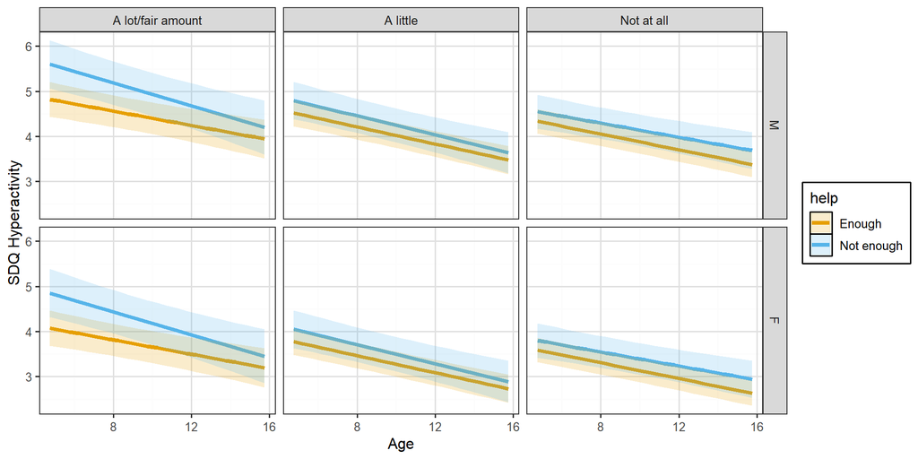

**Highest income plot**

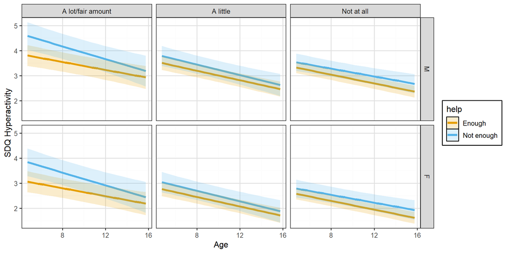

### Sex, income, maternal MH

**Estimates**

[1] “No singular fit” [1] “No convergence issues”

| REML |
| --- |
| 48106.78 |

|  | Dsdhy1 |  |  |  |  |  |  |  |  |  |  |
| --- | --- | --- | --- | --- | --- | --- | --- | --- | --- | --- | --- |
| Predictors | Estimates | std. Error | std. Beta | standardized std. Error | CI | standardized CI | Statistic | std. Statistic | p | std. p | df |
| (Intercept) | 3.87 | 0.13 | 0.23 | 0.05 | 3.61 – 4.13 | 0.12 – 0.33 | 29.46 | 4.28 | **<0.001** | **<0.001** | 12040.00 |
| food help [A little.Enough] | 0.09 | 0.10 | 0.04 | 0.04 | -0.11 – 0.30 | -0.04 – 0.12 | 0.91 | 0.91 | 0.364 | 0.364 | 12040.00 |
| food help [A little.Not enough] | 0.14 | 0.17 | 0.06 | 0.07 | -0.18 – 0.47 | -0.07 – 0.19 | 0.86 | 0.87 | 0.387 | 0.386 | 12040.00 |
| food help [A lot/fair amount.Enough] | 0.40 | 0.17 | 0.16 | 0.07 | 0.06 – 0.73 | 0.03 – 0.30 | 2.33 | 2.33 | **0.020** | **0.020** | 12040.00 |
| food help [A lot/fair amount.Not enough] | 0.73 | 0.24 | 0.29 | 0.10 | 0.26 – 1.19 | 0.11 – 0.48 | 3.07 | 3.07 | **0.002** | **0.002** | 12040.00 |
| food help [Not at all.Not enough] | 0.16 | 0.14 | 0.06 | 0.06 | -0.12 – 0.44 | -0.05 – 0.18 | 1.12 | 1.12 | 0.264 | 0.265 | 12040.00 |
| age cent | -0.09 | 0.01 | -0.12 | 0.01 | -0.10 – -0.07 | -0.14 – -0.10 | -11.19 | -11.19 | **<0.001** | **<0.001** | 12040.00 |
| Sex [F] | -0.73 | 0.08 | -0.29 | 0.03 | -0.89 – -0.56 | -0.36 – -0.23 | -8.80 | -8.80 | **<0.001** | **<0.001** | 12040.00 |
| DeEqv5 [2] | -0.39 | 0.14 | -0.16 | 0.06 | -0.67 – -0.11 | -0.27 – -0.04 | -2.74 | -2.74 | **0.006** | **0.006** | 12040.00 |
| DeEqv5 [3] | -0.59 | 0.15 | -0.24 | 0.06 | -0.87 – -0.30 | -0.35 – -0.12 | -4.03 | -4.03 | **<0.001** | **<0.001** | 12040.00 |
| DeEqv5 [4] | -0.79 | 0.14 | -0.32 | 0.06 | -1.07 – -0.52 | -0.43 – -0.21 | -5.66 | -5.66 | **<0.001** | **<0.001** | 12040.00 |
| DeEqv5 [5] | -0.83 | 0.15 | -0.34 | 0.06 | -1.13 – -0.54 | -0.46 – -0.22 | -5.54 | -5.54 | **<0.001** | **<0.001** | 12040.00 |
| DeSf12mn | -0.35 | 0.04 | -0.14 | 0.02 | -0.44 – -0.27 | -0.18 – -0.11 | -8.27 | -8.27 | **<0.001** | **<0.001** | 12040.00 |
| food help [A little.Enough] × age cent | -0.01 | 0.01 | -0.01 | 0.02 | -0.03 – 0.02 | -0.05 – 0.03 | -0.60 | -0.60 | 0.551 | 0.551 | 12040.00 |
| food help [A little.Not enough] × age cent | -0.02 | 0.02 | -0.03 | 0.03 | -0.06 – 0.02 | -0.08 – 0.03 | -0.84 | -0.84 | 0.400 | 0.400 | 12040.00 |
| food help [A lot/fair amount.Enough] × age cent | 0.01 | 0.02 | 0.01 | 0.03 | -0.03 – 0.05 | -0.05 – 0.07 | 0.43 | 0.43 | 0.666 | 0.666 | 12040.00 |
| food help [A lot/fair amount.Not enough] × age cent | -0.04 | 0.03 | -0.06 | 0.04 | -0.10 – 0.02 | -0.14 – 0.02 | -1.37 | -1.37 | 0.171 | 0.171 | 12040.00 |
| food help [Not at all.Not enough] × age cent | 0.01 | 0.02 | 0.01 | 0.03 | -0.03 – 0.05 | -0.04 – 0.07 | 0.48 | 0.48 | 0.634 | 0.634 | 12040.00 |
| Random Effects |  |  |  |  |  |  |  |  |  |  |  |
| σ<sup>2</sup> | 1.59 |  |  |  |  |  |  |  |  |  |  |
| τ<sub>00</sub> <sub>Idnumber</sub> | 3.12 |  |  |  |  |  |  |  |  |  |  |
| τ<sub>11</sub> <sub>Idnumber.age.cent</sub> | 0.03 |  |  |  |  |  |  |  |  |  |  |
| ρ<sub>01</sub> <sub>Idnumber</sub> | 0.03 |  |  |  |  |  |  |  |  |  |  |
| ICC | 0.69 |  |  |  |  |  |  |  |  |  |  |
| N <sub>Idnumber</sub> | 2035 |  |  |  |  |  |  |  |  |  |  |
| Observations | 12062 |  |  |  |  |  |  |  |  |  |  |
| Marginal R<sup>2</sup> / Conditional R<sup>2</sup> | 0.098 / 0.719 |  |  |  |  |  |  |  |  |  |  |

**Lowest income plot**

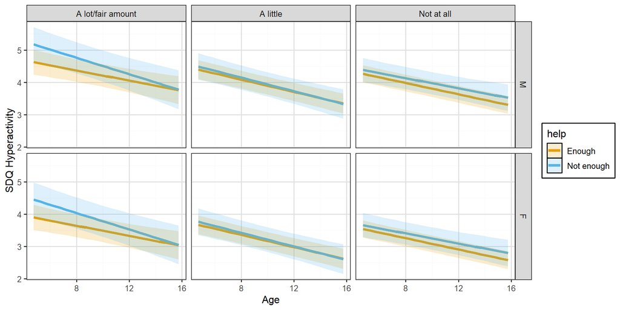

**Highest income plot**

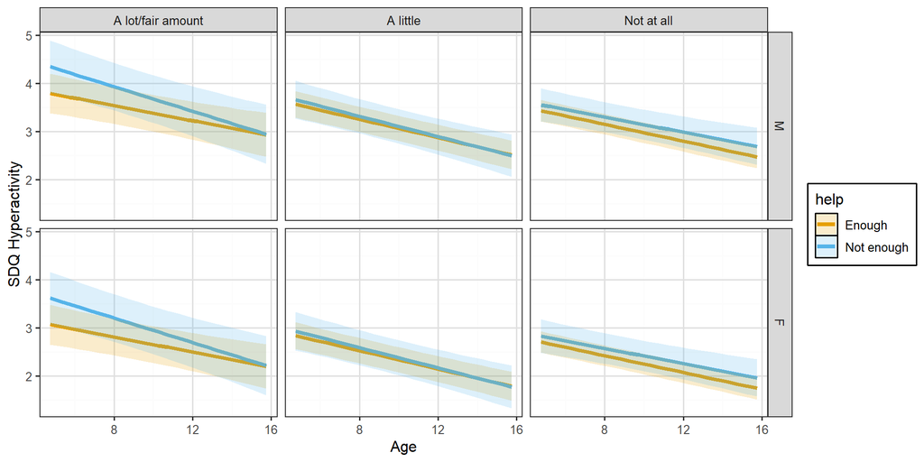

### Sex, income, maternal MH + SIMD

**Estimates**

[1] “No singular fit” [1] “No convergence issues”

| REML |
| --- |
| 48102.52 |

|  | Dsdhy1 |  |  |  |  |  |  |  |  |  |  |
| --- | --- | --- | --- | --- | --- | --- | --- | --- | --- | --- | --- |
| Predictors | Estimates | std. Error | std. Beta | standardized std. Error | CI | standardized CI | Statistic | std. Statistic | p | std. p | df |
| (Intercept) | 3.65 | 0.16 | 0.14 | 0.07 | 3.33 – 3.96 | 0.01 – 0.26 | 22.44 | 2.08 | **<0.001** | **0.038** | 12036.00 |
| food help [A little.Enough] | 0.11 | 0.10 | 0.04 | 0.04 | -0.10 – 0.31 | -0.04 – 0.12 | 1.02 | 1.02 | 0.310 | 0.309 | 12036.00 |
| food help [A little.Not enough] | 0.14 | 0.17 | 0.06 | 0.07 | -0.18 – 0.47 | -0.07 – 0.19 | 0.86 | 0.87 | 0.388 | 0.387 | 12036.00 |
| food help [A lot/fair amount.Enough] | 0.38 | 0.17 | 0.15 | 0.07 | 0.05 – 0.72 | 0.02 – 0.29 | 2.23 | 2.23 | **0.026** | **0.026** | 12036.00 |
| food help [A lot/fair amount.Not enough] | 0.72 | 0.24 | 0.29 | 0.10 | 0.26 – 1.19 | 0.10 – 0.48 | 3.04 | 3.04 | **0.002** | **0.002** | 12036.00 |
| food help [Not at all.Not enough] | 0.17 | 0.14 | 0.07 | 0.06 | -0.11 – 0.46 | -0.04 – 0.18 | 1.21 | 1.21 | 0.226 | 0.226 | 12036.00 |
| age cent | -0.09 | 0.01 | -0.12 | 0.01 | -0.10 – -0.07 | -0.14 – -0.10 | -11.18 | -11.18 | **<0.001** | **<0.001** | 12036.00 |
| Sex [F] | -0.73 | 0.08 | -0.30 | 0.03 | -0.89 – -0.57 | -0.36 – -0.23 | -8.89 | -8.89 | **<0.001** | **<0.001** | 12036.00 |
| DeEqv5 [2] | -0.34 | 0.14 | -0.14 | 0.06 | -0.62 – -0.06 | -0.25 – -0.02 | -2.36 | -2.36 | **0.018** | **0.018** | 12036.00 |
| DeEqv5 [3] | -0.49 | 0.15 | -0.20 | 0.06 | -0.78 – -0.20 | -0.31 – -0.08 | -3.31 | -3.31 | **0.001** | **0.001** | 12036.00 |
| DeEqv5 [4] | -0.65 | 0.15 | -0.26 | 0.06 | -0.93 – -0.36 | -0.38 – -0.15 | -4.44 | -4.44 | **<0.001** | **<0.001** | 12036.00 |
| DeEqv5 [5] | -0.66 | 0.16 | -0.26 | 0.06 | -0.97 – -0.35 | -0.39 – -0.14 | -4.13 | -4.13 | **<0.001** | **<0.001** | 12036.00 |
| DeSf12mn | -0.35 | 0.04 | -0.14 | 0.02 | -0.43 – -0.26 | -0.17 – -0.11 | -8.07 | -8.07 | **<0.001** | **<0.001** | 12036.00 |
| ALeSNim2 [2] | -0.01 | 0.12 | -0.00 | 0.05 | -0.24 – 0.22 | -0.10 – 0.09 | -0.09 | -0.09 | 0.928 | 0.928 | 12036.00 |
| ALeSNim2 [3] | 0.12 | 0.13 | 0.05 | 0.05 | -0.13 – 0.36 | -0.05 – 0.15 | 0.93 | 0.93 | 0.352 | 0.352 | 12036.00 |
| ALeSNim2 [4] | 0.24 | 0.14 | 0.10 | 0.05 | -0.03 – 0.50 | -0.01 – 0.20 | 1.75 | 1.75 | 0.080 | 0.080 | 12036.00 |
| ALeSNim2 [5] | 0.49 | 0.15 | 0.20 | 0.06 | 0.19 – 0.79 | 0.08 – 0.32 | 3.22 | 3.22 | **0.001** | **0.001** | 12036.00 |
| food help [A little.Enough] × age cent | -0.01 | 0.01 | -0.01 | 0.02 | -0.03 – 0.02 | -0.05 – 0.03 | -0.60 | -0.60 | 0.550 | 0.550 | 12036.00 |
| food help [A little.Not enough] × age cent | -0.02 | 0.02 | -0.03 | 0.03 | -0.06 – 0.02 | -0.08 – 0.03 | -0.84 | -0.84 | 0.400 | 0.400 | 12036.00 |
| food help [A lot/fair amount.Enough] × age cent | 0.01 | 0.02 | 0.01 | 0.03 | -0.03 – 0.05 | -0.05 – 0.07 | 0.43 | 0.43 | 0.667 | 0.667 | 12036.00 |
| food help [A lot/fair amount.Not enough] × age cent | -0.04 | 0.03 | -0.06 | 0.04 | -0.10 – 0.02 | -0.14 – 0.02 | -1.37 | -1.37 | 0.171 | 0.171 | 12036.00 |
| food help [Not at all.Not enough] × age cent | 0.01 | 0.02 | 0.01 | 0.03 | -0.03 – 0.05 | -0.04 – 0.07 | 0.47 | 0.47 | 0.635 | 0.635 | 12036.00 |
| Random Effects |  |  |  |  |  |  |  |  |  |  |  |
| σ<sup>2</sup> | 1.59 |  |  |  |  |  |  |  |  |  |  |
| τ<sub>00</sub> <sub>Idnumber</sub> | 3.10 |  |  |  |  |  |  |  |  |  |  |
| τ<sub>11</sub> <sub>Idnumber.age.cent</sub> | 0.03 |  |  |  |  |  |  |  |  |  |  |
| ρ<sub>01</sub> <sub>Idnumber</sub> | 0.04 |  |  |  |  |  |  |  |  |  |  |
| ICC | 0.69 |  |  |  |  |  |  |  |  |  |  |
| N <sub>Idnumber</sub> | 2035 |  |  |  |  |  |  |  |  |  |  |
| Observations | 12062 |  |  |  |  |  |  |  |  |  |  |
| Marginal R<sup>2</sup> / Conditional R<sup>2</sup> | 0.102 / 0.719 |  |  |  |  |  |  |  |  |  |  |

**Contrasts**

| Age | contrast | null.value | estimate | std.error | df | statistic | p.value |
| --- | --- | --- | --- | --- | --- | --- | --- |
| 5 | Not at all.Not enough vs Enough | 0 | 0.135 | 0.163 | 2090.499 | 0.831 | 0.406 |
| 5 | A little.Not enough vs Enough | 0 | 0.081 | 0.199 | 2062.888 | 0.409 | 0.682 |
| 5 | A lot/fair amount.Not enough vs Enough | 0 | 0.549 | 0.305 | 1918.370 | 1.798 | 0.072 |
| 6 | Not at all.Not enough vs Enough | 0 | 0.144 | 0.155 | 2075.611 | 0.933 | 0.351 |
| 6 | A little.Not enough vs Enough | 0 | 0.071 | 0.190 | 2053.516 | 0.377 | 0.706 |
| 6 | A lot/fair amount.Not enough vs Enough | 0 | 0.500 | 0.291 | 1934.881 | 1.715 | 0.086 |
| 7 | Not at all.Not enough vs Enough | 0 | 0.153 | 0.149 | 2064.314 | 1.031 | 0.303 |
| 7 | A little.Not enough vs Enough | 0 | 0.061 | 0.182 | 2045.520 | 0.337 | 0.736 |
| 7 | A lot/fair amount.Not enough vs Enough | 0 | 0.451 | 0.281 | 1950.253 | 1.604 | 0.109 |
| 8 | Not at all.Not enough vs Enough | 0 | 0.162 | 0.145 | 2057.604 | 1.120 | 0.263 |
| 8 | A little.Not enough vs Enough | 0 | 0.051 | 0.178 | 2039.647 | 0.289 | 0.773 |
| 8 | A lot/fair amount.Not enough vs Enough | 0 | 0.402 | 0.274 | 1961.899 | 1.464 | 0.143 |
| 9 | Not at all.Not enough vs Enough | 0 | 0.171 | 0.144 | 2056.394 | 1.194 | 0.233 |
| 9 | A little.Not enough vs Enough | 0 | 0.041 | 0.176 | 2036.933 | 0.235 | 0.815 |
| 9 | A lot/fair amount.Not enough vs Enough | 0 | 0.353 | 0.272 | 1967.827 | 1.296 | 0.195 |
| 10 | Not at all.Not enough vs Enough | 0 | 0.180 | 0.145 | 2061.470 | 1.247 | 0.213 |
| 10 | A little.Not enough vs Enough | 0 | 0.031 | 0.177 | 2038.510 | 0.176 | 0.860 |
| 10 | A lot/fair amount.Not enough vs Enough | 0 | 0.304 | 0.274 | 1967.695 | 1.108 | 0.268 |
| 11 | Not at all.Not enough vs Enough | 0 | 0.190 | 0.148 | 2073.199 | 1.277 | 0.202 |
| 11 | A little.Not enough vs Enough | 0 | 0.021 | 0.182 | 2045.127 | 0.117 | 0.907 |
| 11 | A lot/fair amount.Not enough vs Enough | 0 | 0.255 | 0.280 | 1962.959 | 0.909 | 0.363 |
| 12 | Not at all.Not enough vs Enough | 0 | 0.199 | 0.154 | 2091.142 | 1.287 | 0.198 |
| 12 | A little.Not enough vs Enough | 0 | 0.011 | 0.188 | 2056.673 | 0.060 | 0.952 |
| 12 | A lot/fair amount.Not enough vs Enough | 0 | 0.206 | 0.290 | 1955.953 | 0.709 | 0.479 |
| 13 | Not at all.Not enough vs Enough | 0 | 0.208 | 0.162 | 2113.959 | 1.280 | 0.201 |
| 13 | A little.Not enough vs Enough | 0 | 0.001 | 0.198 | 2072.127 | 0.006 | 0.995 |
| 13 | A lot/fair amount.Not enough vs Enough | 0 | 0.157 | 0.304 | 1948.735 | 0.516 | 0.606 |
| 14 | Not at all.Not enough vs Enough | 0 | 0.217 | 0.172 | 2139.744 | 1.261 | 0.208 |
| 14 | A little.Not enough vs Enough | 0 | -0.009 | 0.209 | 2089.939 | -0.042 | 0.966 |
| 14 | A lot/fair amount.Not enough vs Enough | 0 | 0.108 | 0.321 | 1942.498 | 0.336 | 0.737 |
| 15 | Not at all.Not enough vs Enough | 0 | 0.226 | 0.183 | 2166.556 | 1.234 | 0.218 |
| 15 | A little.Not enough vs Enough | 0 | -0.019 | 0.222 | 2108.538 | -0.085 | 0.933 |
| 15 | A lot/fair amount.Not enough vs Enough | 0 | 0.059 | 0.340 | 1937.621 | 0.173 | 0.863 |
| 16 | Not at all.Not enough vs Enough | 0 | 0.235 | 0.195 | 2192.815 | 1.202 | 0.230 |
| 16 | A little.Not enough vs Enough | 0 | -0.029 | 0.237 | 2126.676 | -0.122 | 0.903 |
| 16 | A lot/fair amount.Not enough vs Enough | 0 | 0.010 | 0.361 | 1934.002 | 0.027 | 0.979 |

**Lowest income plot**

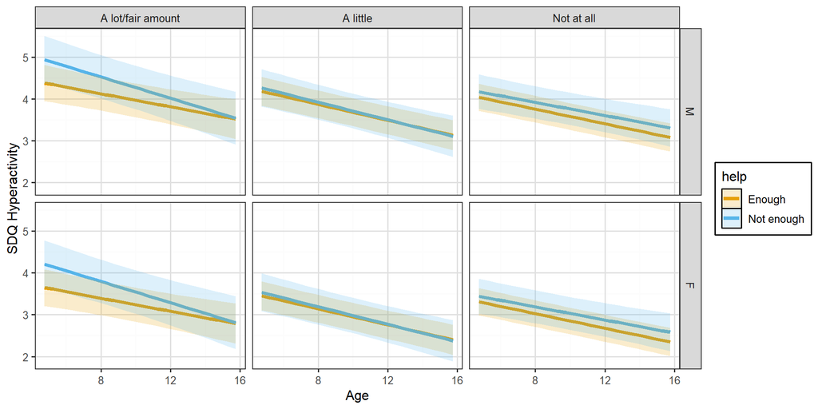

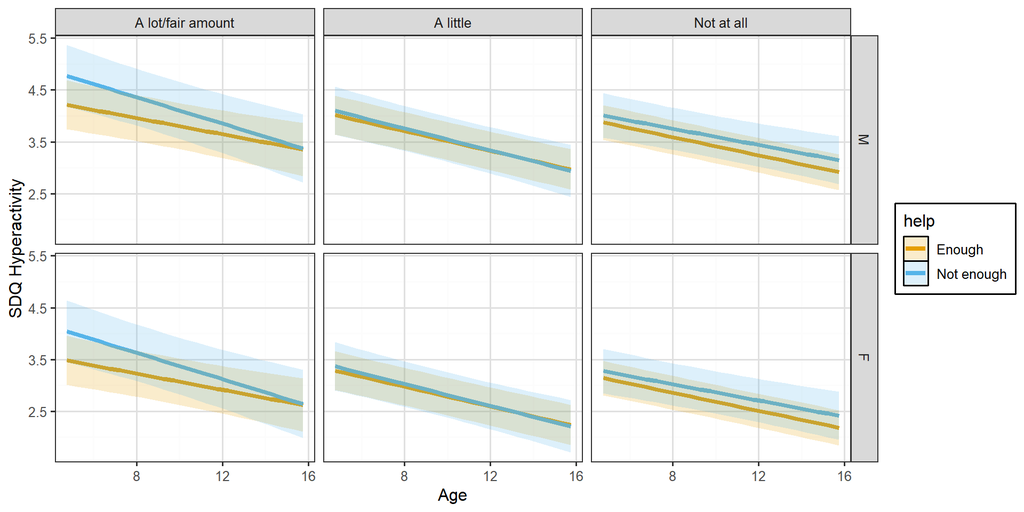

## Peer problems

### No Covariates

**Estimates**

[1] “No singular fit” [1] “No convergence issues”

| REML |
| --- |
| 41327.59 |

|  | Dsdpr1 |  |  |  |  |  |  |  |  |  |  |
| --- | --- | --- | --- | --- | --- | --- | --- | --- | --- | --- | --- |
| Predictors | Estimates | std. Error | std. Beta | standardized std. Error | CI | standardized CI | Statistic | std. Statistic | p | std. p | df |
| (Intercept) | 0.91 | 0.04 | -0.21 | 0.03 | 0.82 – 0.99 | -0.27 – -0.16 | 20.55 | -8.05 | **<0.001** | **<0.001** | 12058.00 |
| food help [A little.Enough] | 0.16 | 0.08 | 0.10 | 0.05 | 0.02 – 0.31 | 0.01 – 0.19 | 2.17 | 2.17 | **0.030** | **0.030** | 12058.00 |
| food help [A little.Not enough] | 0.67 | 0.12 | 0.41 | 0.07 | 0.44 – 0.91 | 0.26 – 0.55 | 5.55 | 5.54 | **<0.001** | **<0.001** | 12058.00 |
| food help [A lot/fair amount.Enough] | 0.75 | 0.12 | 0.45 | 0.07 | 0.51 – 0.98 | 0.31 – 0.59 | 6.31 | 6.31 | **<0.001** | **<0.001** | 12058.00 |
| food help [A lot/fair amount.Not enough] | 0.87 | 0.17 | 0.52 | 0.10 | 0.54 – 1.19 | 0.33 – 0.72 | 5.24 | 5.25 | **<0.001** | **<0.001** | 12058.00 |
| food help [Not at all.Not enough] | 0.41 | 0.11 | 0.25 | 0.06 | 0.20 – 0.62 | 0.12 – 0.37 | 3.86 | 3.85 | **<0.001** | **<0.001** | 12058.00 |
| age cent | 0.07 | 0.01 | 0.14 | 0.03 | 0.04 – 0.09 | 0.08 – 0.20 | 4.93 | 4.91 | **<0.001** | **<0.001** | 12058.00 |
| age cent^2 | 0.00 | 0.01 | 0.03 | 0.04 | -0.01 – 0.01 | -0.05 – 0.10 | 0.65 | 0.66 | 0.517 | 0.512 | 12058.00 |
| age cent^3 | -0.00 | 0.00 | -0.03 | 0.02 | -0.00 – 0.00 | -0.07 – 0.01 | -1.62 | -1.61 | 0.105 | 0.107 | 12058.00 |
| age cent^4 | 0.00 | 0.00 | 0.00 | 0.02 | -0.00 – 0.00 | -0.03 – 0.04 | 0.11 | 0.11 | 0.914 | 0.914 | 12058.00 |
| food help [A little.Enough] × age cent | 0.02 | 0.02 | 0.04 | 0.05 | -0.03 – 0.06 | -0.06 – 0.13 | 0.79 | 0.80 | 0.427 | 0.425 | 12058.00 |
| food help [A little.Not enough] × age cent | 0.08 | 0.04 | 0.17 | 0.08 | 0.01 – 0.15 | 0.01 – 0.32 | 2.13 | 2.14 | **0.033** | **0.033** | 12058.00 |
| food help [A lot/fair amount.Enough] × age cent | 0.09 | 0.03 | 0.18 | 0.07 | 0.02 – 0.15 | 0.04 – 0.32 | 2.54 | 2.56 | **0.011** | **0.011** | 12058.00 |
| food help [A lot/fair amount.Not enough] × age cent | -0.04 | 0.05 | -0.08 | 0.10 | -0.13 – 0.05 | -0.27 – 0.11 | -0.84 | -0.83 | 0.400 | 0.404 | 12058.00 |
| food help [Not at all.Not enough] × age cent | 0.07 | 0.03 | 0.14 | 0.07 | 0.00 – 0.13 | 0.01 – 0.28 | 2.09 | 2.09 | **0.037** | **0.037** | 12058.00 |
| food help [A little.Enough] × age cent^2 | -0.01 | 0.01 | -0.04 | 0.07 | -0.02 – 0.01 | -0.18 – 0.09 | -0.65 | -0.65 | 0.514 | 0.513 | 12058.00 |
| food help [A little.Not enough] × age cent^2 | -0.03 | 0.01 | -0.21 | 0.11 | -0.06 – -0.00 | -0.43 – -0.00 | -1.99 | -1.99 | **0.046** | **0.046** | 12058.00 |
| food help [A lot/fair amount.Enough] × age cent^2 | -0.03 | 0.01 | -0.24 | 0.10 | -0.06 – -0.01 | -0.43 – -0.04 | -2.41 | -2.40 | **0.016** | **0.016** | 12058.00 |
| food help [A lot/fair amount.Not enough] × age cent^2 | -0.01 | 0.02 | -0.10 | 0.14 | -0.05 – 0.03 | -0.38 – 0.18 | -0.68 | -0.69 | 0.496 | 0.493 | 12058.00 |
| food help [Not at all.Not enough] × age cent^2 | -0.02 | 0.01 | -0.14 | 0.10 | -0.04 – 0.01 | -0.33 – 0.05 | -1.45 | -1.45 | 0.148 | 0.148 | 12058.00 |
| food help [A little.Enough] × age cent^3 | 0.00 | 0.00 | -0.00 | 0.03 | -0.00 – 0.00 | -0.06 – 0.06 | 0.01 | -0.00 | 0.996 | 0.997 | 12058.00 |
| food help [A little.Not enough] × age cent^3 | -0.00 | 0.00 | -0.06 | 0.05 | -0.01 – 0.00 | -0.16 – 0.04 | -1.22 | -1.23 | 0.222 | 0.219 | 12058.00 |
| food help [A lot/fair amount.Enough] × age cent^3 | -0.00 | 0.00 | -0.10 | 0.05 | -0.01 – -0.00 | -0.19 – -0.01 | -2.16 | -2.18 | **0.030** | **0.030** | 12058.00 |
| food help [A lot/fair amount.Not enough] × age cent^3 | 0.00 | 0.00 | 0.08 | 0.06 | -0.00 – 0.01 | -0.05 – 0.20 | 1.24 | 1.23 | 0.214 | 0.218 | 12058.00 |
| food help [Not at all.Not enough] × age cent^3 | -0.00 | 0.00 | -0.04 | 0.05 | -0.01 – 0.00 | -0.13 – 0.05 | -0.91 | -0.92 | 0.363 | 0.359 | 12058.00 |
| food help [A little.Enough] × age cent^4 | 0.00 | 0.00 | 0.03 | 0.03 | -0.00 – 0.00 | -0.04 – 0.09 | 0.85 | 0.85 | 0.394 | 0.394 | 12058.00 |
| food help [A little.Not enough] × age cent^4 | 0.00 | 0.00 | 0.08 | 0.05 | -0.00 – 0.00 | -0.02 – 0.18 | 1.62 | 1.62 | 0.105 | 0.105 | 12058.00 |
| food help [A lot/fair amount.Enough] × age cent^4 | 0.00 | 0.00 | 0.12 | 0.05 | 0.00 – 0.00 | 0.03 – 0.21 | 2.51 | 2.51 | **0.012** | **0.012** | 12058.00 |
| food help [A lot/fair amount.Not enough] × age cent^4 | 0.00 | 0.00 | 0.02 | 0.07 | -0.00 – 0.00 | -0.12 – 0.15 | 0.27 | 0.27 | 0.787 | 0.787 | 12058.00 |
| food help [Not at all.Not enough] × age cent^4 | 0.00 | 0.00 | 0.06 | 0.05 | -0.00 – 0.00 | -0.03 – 0.15 | 1.37 | 1.37 | 0.170 | 0.170 | 12058.00 |
| Random Effects |  |  |  |  |  |  |  |  |  |  |  |
| σ<sup>2</sup> | 0.99 |  |  |  |  |  |  |  |  |  |  |
| τ<sub>00</sub> <sub>Idnumber</sub> | 1.13 |  |  |  |  |  |  |  |  |  |  |
| τ<sub>11</sub> <sub>Idnumber.age.cent</sub> | 0.02 |  |  |  |  |  |  |  |  |  |  |
| ρ<sub>01</sub> <sub>Idnumber</sub> | 0.51 |  |  |  |  |  |  |  |  |  |  |
| ICC | 0.58 |  |  |  |  |  |  |  |  |  |  |
| N <sub>Idnumber</sub> | 2041 |  |  |  |  |  |  |  |  |  |  |
| Observations | 12092 |  |  |  |  |  |  |  |  |  |  |
| Marginal R<sup>2</sup> / Conditional R<sup>2</sup> | 0.043 / 0.600 |  |  |  |  |  |  |  |  |  |  |

**Contrasts**

| Age | contrast | null.value | estimate | std.error | df | statistic | p.value |
| --- | --- | --- | --- | --- | --- | --- | --- |
| 5 | Not at all.Not enough vs Enough | 0 | 0.134 | 0.098 | 3171.416 | 1.367 | 0.172 |
| 5 | A little.Not enough vs Enough | 0 | 0.223 | 0.118 | 3017.218 | 1.891 | 0.059 |
| 5 | A lot/fair amount.Not enough vs Enough | 0 | 0.092 | 0.175 | 2472.376 | 0.528 | 0.598 |
| 6 | Not at all.Not enough vs Enough | 0 | 0.122 | 0.099 | 3894.194 | 1.231 | 0.218 |
| 6 | A little.Not enough vs Enough | 0 | 0.219 | 0.120 | 3719.929 | 1.829 | 0.068 |
| 6 | A lot/fair amount.Not enough vs Enough | 0 | 0.363 | 0.178 | 3092.089 | 2.039 | 0.042 |
| 7 | Not at all.Not enough vs Enough | 0 | 0.196 | 0.101 | 4357.415 | 1.941 | 0.052 |
| 7 | A little.Not enough vs Enough | 0 | 0.297 | 0.122 | 4163.629 | 2.440 | 0.015 |
| 7 | A lot/fair amount.Not enough vs Enough | 0 | 0.392 | 0.181 | 3444.474 | 2.169 | 0.030 |
| 8 | Not at all.Not enough vs Enough | 0 | 0.299 | 0.099 | 3833.405 | 3.032 | 0.002 |
| 8 | A little.Not enough vs Enough | 0 | 0.402 | 0.119 | 3681.353 | 3.373 | 0.001 |
| 8 | A lot/fair amount.Not enough vs Enough | 0 | 0.293 | 0.178 | 3137.921 | 1.643 | 0.100 |
| 9 | Not at all.Not enough vs Enough | 0 | 0.392 | 0.105 | 4061.023 | 3.744 | 0.000 |
| 9 | A little.Not enough vs Enough | 0 | 0.492 | 0.127 | 3921.070 | 3.889 | 0.000 |
| 9 | A lot/fair amount.Not enough vs Enough | 0 | 0.156 | 0.190 | 3369.264 | 0.824 | 0.410 |
| 10 | Not at all.Not enough vs Enough | 0 | 0.451 | 0.111 | 4050.508 | 4.051 | 0.000 |
| 10 | A little.Not enough vs Enough | 0 | 0.541 | 0.135 | 3919.662 | 4.017 | 0.000 |
| 10 | A lot/fair amount.Not enough vs Enough | 0 | 0.043 | 0.201 | 3331.797 | 0.214 | 0.831 |
| 11 | Not at all.Not enough vs Enough | 0 | 0.471 | 0.114 | 3416.069 | 4.118 | 0.000 |
| 11 | A little.Not enough vs Enough | 0 | 0.537 | 0.138 | 3313.465 | 3.880 | 0.000 |
| 11 | A lot/fair amount.Not enough vs Enough | 0 | -0.011 | 0.208 | 2843.459 | -0.053 | 0.958 |
| 12 | Not at all.Not enough vs Enough | 0 | 0.463 | 0.121 | 3101.068 | 3.822 | 0.000 |
| 12 | A little.Not enough vs Enough | 0 | 0.485 | 0.147 | 3019.215 | 3.303 | 0.001 |
| 12 | A lot/fair amount.Not enough vs Enough | 0 | 0.004 | 0.222 | 2680.262 | 0.016 | 0.987 |
| 13 | Not at all.Not enough vs Enough | 0 | 0.454 | 0.133 | 3207.795 | 3.409 | 0.001 |
| 13 | A little.Not enough vs Enough | 0 | 0.403 | 0.162 | 3129.686 | 2.490 | 0.013 |
| 13 | A lot/fair amount.Not enough vs Enough | 0 | 0.069 | 0.245 | 2797.238 | 0.282 | 0.778 |
| 14 | Not at all.Not enough vs Enough | 0 | 0.490 | 0.139 | 2763.761 | 3.520 | 0.000 |
| 14 | A little.Not enough vs Enough | 0 | 0.323 | 0.168 | 2676.643 | 1.918 | 0.055 |
| 14 | A lot/fair amount.Not enough vs Enough | 0 | 0.141 | 0.255 | 2358.640 | 0.555 | 0.579 |
| 15 | Not at all.Not enough vs Enough | 0 | 0.631 | 0.170 | 4044.460 | 3.708 | 0.000 |
| 15 | A little.Not enough vs Enough | 0 | 0.295 | 0.202 | 3748.195 | 1.458 | 0.145 |
| 15 | A lot/fair amount.Not enough vs Enough | 0 | 0.150 | 0.311 | 3574.072 | 0.484 | 0.629 |
| 16 | Not at all.Not enough vs Enough | 0 | 0.956 | 0.362 | 10499.851 | 2.640 | 0.008 |
| 16 | A little.Not enough vs Enough | 0 | 0.382 | 0.428 | 10433.991 | 0.892 | 0.373 |
| 16 | A lot/fair amount.Not enough vs Enough | 0 | -0.001 | 0.655 | 10448.071 | -0.002 | 0.999 |

**Plot**

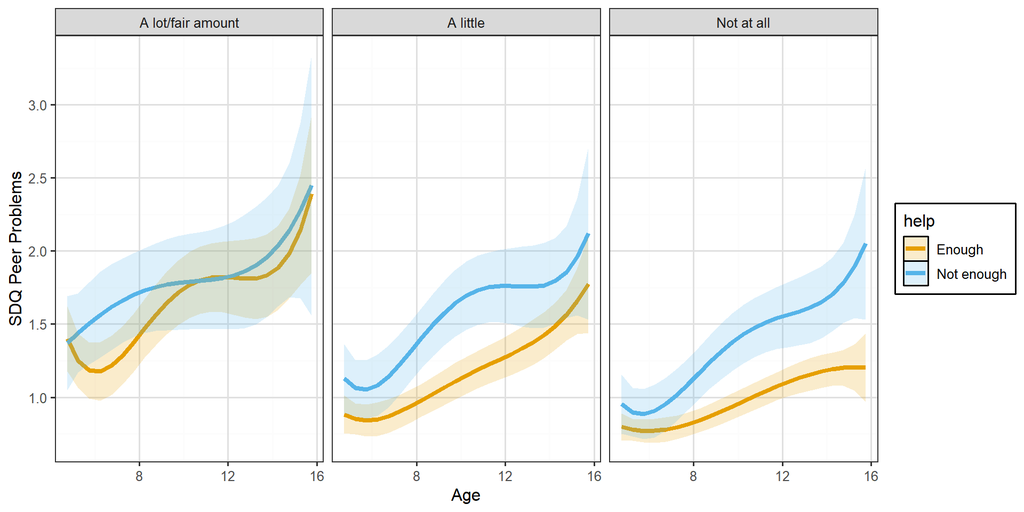

### Covariates sex and income

**Estimates**

[1] “No singular fit” [1] “No convergence issues”

| REML |
| --- |
| 41265.96 |

|  | Dsdpr1 |  |  |  |  |  |  |  |  |  |  |
| --- | --- | --- | --- | --- | --- | --- | --- | --- | --- | --- | --- |
| Predictors | Estimates | std. Error | std. Beta | standardized std. Error | CI | standardized CI | Statistic | std. Statistic | p | std. p | df |
| (Intercept) | 1.40 | 0.08 | 0.08 | 0.05 | 1.24 – 1.55 | -0.01 – 0.17 | 17.80 | 1.74 | **<0.001** | 0.082 | 12053.00 |
| food help [A little.Enough] | 0.10 | 0.08 | 0.06 | 0.05 | -0.05 – 0.25 | -0.03 – 0.15 | 1.33 | 1.33 | 0.184 | 0.185 | 12053.00 |
| food help [A little.Not enough] | 0.60 | 0.12 | 0.36 | 0.07 | 0.36 – 0.83 | 0.22 – 0.50 | 4.97 | 4.97 | **<0.001** | **<0.001** | 12053.00 |
| food help [A lot/fair amount.Enough] | 0.54 | 0.12 | 0.32 | 0.07 | 0.31 – 0.77 | 0.18 – 0.46 | 4.55 | 4.55 | **<0.001** | **<0.001** | 12053.00 |
| food help [A lot/fair amount.Not enough] | 0.69 | 0.16 | 0.42 | 0.10 | 0.37 – 1.02 | 0.22 – 0.61 | 4.24 | 4.24 | **<0.001** | **<0.001** | 12053.00 |
| food help [Not at all.Not enough] | 0.39 | 0.11 | 0.23 | 0.06 | 0.18 – 0.60 | 0.11 – 0.36 | 3.71 | 3.71 | **<0.001** | **<0.001** | 12053.00 |
| age cent | 0.07 | 0.01 | 0.14 | 0.03 | 0.04 – 0.09 | 0.09 – 0.20 | 5.01 | 5.00 | **<0.001** | **<0.001** | 12053.00 |
| age cent^2 | 0.00 | 0.01 | 0.03 | 0.04 | -0.01 – 0.01 | -0.05 – 0.10 | 0.64 | 0.65 | 0.523 | 0.519 | 12053.00 |
| age cent^3 | -0.00 | 0.00 | -0.03 | 0.02 | -0.00 – 0.00 | -0.07 – 0.01 | -1.63 | -1.62 | 0.103 | 0.105 | 12053.00 |
| age cent^4 | 0.00 | 0.00 | 0.00 | 0.02 | -0.00 – 0.00 | -0.03 – 0.04 | 0.12 | 0.12 | 0.905 | 0.905 | 12053.00 |
| Sex [F] | -0.18 | 0.05 | -0.11 | 0.03 | -0.28 – -0.09 | -0.17 – -0.06 | -3.92 | -3.92 | **<0.001** | **<0.001** | 12053.00 |
| DeEqv5 [2] | -0.24 | 0.08 | -0.14 | 0.05 | -0.39 – -0.08 | -0.24 – -0.05 | -3.01 | -3.01 | **0.003** | **0.003** | 12053.00 |
| DeEqv5 [3] | -0.31 | 0.08 | -0.19 | 0.05 | -0.47 – -0.15 | -0.28 – -0.09 | -3.79 | -3.79 | **<0.001** | **<0.001** | 12053.00 |
| DeEqv5 [4] | -0.52 | 0.08 | -0.32 | 0.05 | -0.68 – -0.37 | -0.41 – -0.22 | -6.69 | -6.69 | **<0.001** | **<0.001** | 12053.00 |
| DeEqv5 [5] | -0.59 | 0.08 | -0.36 | 0.05 | -0.76 – -0.43 | -0.46 – -0.26 | -7.04 | -7.04 | **<0.001** | **<0.001** | 12053.00 |
| food help [A little.Enough] × age cent | 0.02 | 0.02 | 0.04 | 0.05 | -0.03 – 0.06 | -0.06 – 0.13 | 0.80 | 0.80 | 0.427 | 0.425 | 12053.00 |
| food help [A little.Not enough] × age cent | 0.08 | 0.04 | 0.17 | 0.08 | 0.01 – 0.15 | 0.01 – 0.32 | 2.13 | 2.14 | **0.033** | **0.032** | 12053.00 |
| food help [A lot/fair amount.Enough] × age cent | 0.09 | 0.03 | 0.18 | 0.07 | 0.02 – 0.15 | 0.04 – 0.32 | 2.55 | 2.56 | **0.011** | **0.010** | 12053.00 |
| food help [A lot/fair amount.Not enough] × age cent | -0.04 | 0.05 | -0.08 | 0.10 | -0.13 – 0.05 | -0.27 – 0.11 | -0.83 | -0.82 | 0.408 | 0.412 | 12053.00 |
| food help [Not at all.Not enough] × age cent | 0.07 | 0.03 | 0.14 | 0.07 | 0.00 – 0.13 | 0.01 – 0.28 | 2.08 | 2.09 | **0.037** | **0.037** | 12053.00 |
| food help [A little.Enough] × age cent^2 | -0.01 | 0.01 | -0.04 | 0.07 | -0.02 – 0.01 | -0.18 – 0.09 | -0.65 | -0.65 | 0.518 | 0.517 | 12053.00 |
| food help [A little.Not enough] × age cent^2 | -0.03 | 0.01 | -0.21 | 0.11 | -0.06 – -0.00 | -0.43 – -0.00 | -1.99 | -1.99 | **0.047** | **0.047** | 12053.00 |
| food help [A lot/fair amount.Enough] × age cent^2 | -0.03 | 0.01 | -0.24 | 0.10 | -0.06 – -0.01 | -0.43 – -0.04 | -2.41 | -2.41 | **0.016** | **0.016** | 12053.00 |
| food help [A lot/fair amount.Not enough] × age cent^2 | -0.01 | 0.02 | -0.10 | 0.14 | -0.05 – 0.03 | -0.38 – 0.18 | -0.68 | -0.68 | 0.497 | 0.493 | 12053.00 |
| food help [Not at all.Not enough] × age cent^2 | -0.02 | 0.01 | -0.14 | 0.10 | -0.04 – 0.01 | -0.33 – 0.05 | -1.44 | -1.44 | 0.149 | 0.149 | 12053.00 |
| food help [A little.Enough] × age cent^3 | 0.00 | 0.00 | -0.00 | 0.03 | -0.00 – 0.00 | -0.06 – 0.06 | 0.01 | -0.00 | 0.993 | 1.000 | 12053.00 |
| food help [A little.Not enough] × age cent^3 | -0.00 | 0.00 | -0.06 | 0.05 | -0.01 – 0.00 | -0.16 – 0.04 | -1.22 | -1.23 | 0.223 | 0.220 | 12053.00 |
| food help [A lot/fair amount.Enough] × age cent^3 | -0.00 | 0.00 | -0.10 | 0.05 | -0.01 – -0.00 | -0.19 – -0.01 | -2.17 | -2.18 | **0.030** | **0.029** | 12053.00 |
| food help [A lot/fair amount.Not enough] × age cent^3 | 0.00 | 0.00 | 0.08 | 0.06 | -0.00 – 0.01 | -0.05 – 0.20 | 1.24 | 1.23 | 0.214 | 0.219 | 12053.00 |
| food help [Not at all.Not enough] × age cent^3 | -0.00 | 0.00 | -0.04 | 0.05 | -0.01 – 0.00 | -0.13 – 0.05 | -0.91 | -0.92 | 0.364 | 0.360 | 12053.00 |
| food help [A little.Enough] × age cent^4 | 0.00 | 0.00 | 0.03 | 0.03 | -0.00 – 0.00 | -0.04 – 0.09 | 0.85 | 0.85 | 0.397 | 0.397 | 12053.00 |
| food help [A little.Not enough] × age cent^4 | 0.00 | 0.00 | 0.08 | 0.05 | -0.00 – 0.00 | -0.02 – 0.18 | 1.61 | 1.61 | 0.107 | 0.107 | 12053.00 |
| food help [A lot/fair amount.Enough] × age cent^4 | 0.00 | 0.00 | 0.12 | 0.05 | 0.00 – 0.00 | 0.03 – 0.21 | 2.52 | 2.52 | **0.012** | **0.012** | 12053.00 |
| food help [A lot/fair amount.Not enough] × age cent^4 | 0.00 | 0.00 | 0.02 | 0.07 | -0.00 – 0.00 | -0.12 – 0.15 | 0.27 | 0.27 | 0.788 | 0.788 | 12053.00 |
| food help [Not at all.Not enough] × age cent^4 | 0.00 | 0.00 | 0.06 | 0.05 | -0.00 – 0.00 | -0.03 – 0.15 | 1.37 | 1.37 | 0.171 | 0.171 | 12053.00 |
| Random Effects |  |  |  |  |  |  |  |  |  |  |  |
| σ<sup>2</sup> | 0.99 |  |  |  |  |  |  |  |  |  |  |
| τ<sub>00</sub> <sub>Idnumber</sub> | 1.08 |  |  |  |  |  |  |  |  |  |  |
| τ<sub>11</sub> <sub>Idnumber.age.cent</sub> | 0.02 |  |  |  |  |  |  |  |  |  |  |
| ρ<sub>01</sub> <sub>Idnumber</sub> | 0.50 |  |  |  |  |  |  |  |  |  |  |
| ICC | 0.57 |  |  |  |  |  |  |  |  |  |  |
| N <sub>Idnumber</sub> | 2041 |  |  |  |  |  |  |  |  |  |  |
| Observations | 12092 |  |  |  |  |  |  |  |  |  |  |
| Marginal R<sup>2</sup> / Conditional R<sup>2</sup> | 0.062 / 0.598 |  |  |  |  |  |  |  |  |  |  |

**Lowest income plot**

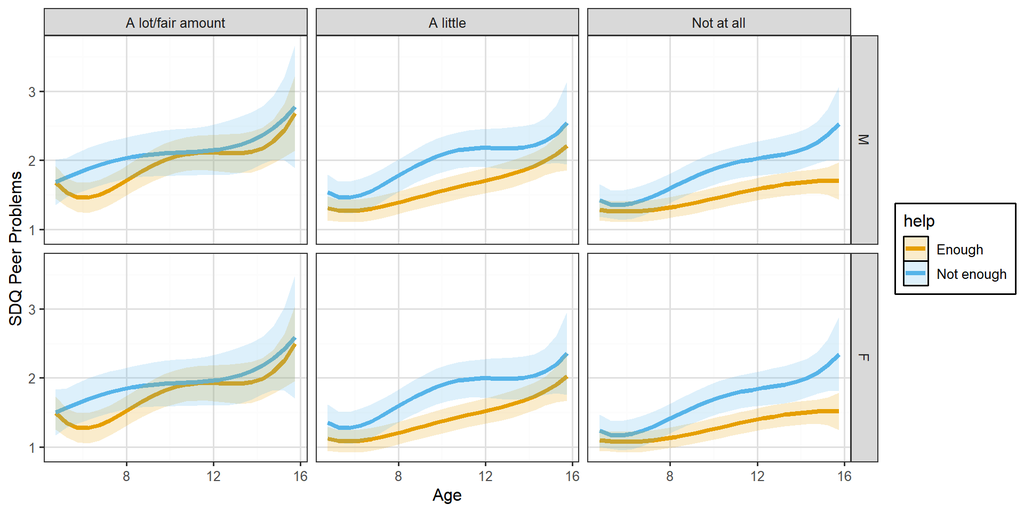

**Highest income plot**

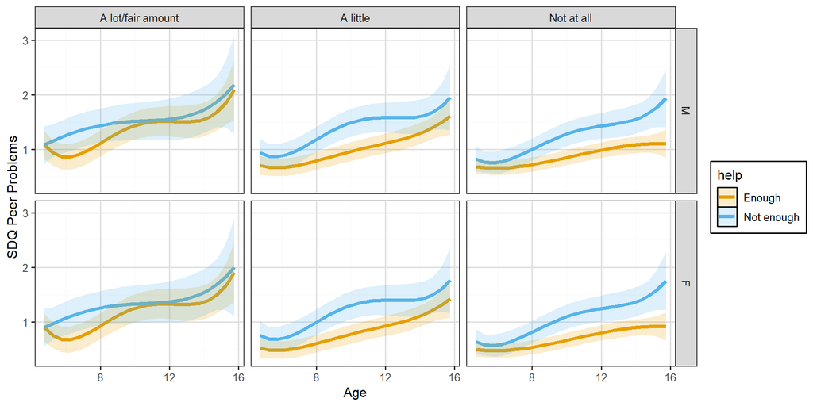

### Sex, income, maternal MH

**Estimates**

[1] “No singular fit” [1] “No convergence issues”

| REML |
| --- |
| 41064.69 |

|  | Dsdpr1 |  |  |  |  |  |  |  |  |  |  |
| --- | --- | --- | --- | --- | --- | --- | --- | --- | --- | --- | --- |
| Predictors | Estimates | std. Error | std. Beta | standardized std. Error | CI | standardized CI | Statistic | std. Statistic | p | std. p | df |
| (Intercept) | 1.35 | 0.08 | 0.06 | 0.05 | 1.20 – 1.50 | -0.03 – 0.15 | 17.45 | 1.25 | **<0.001** | 0.211 | 12022.00 |
| food help [A little.Enough] | 0.07 | 0.07 | 0.04 | 0.05 | -0.08 – 0.21 | -0.05 – 0.13 | 0.91 | 0.90 | 0.365 | 0.366 | 12022.00 |
| food help [A little.Not enough] | 0.48 | 0.12 | 0.29 | 0.07 | 0.25 – 0.72 | 0.15 – 0.43 | 4.03 | 4.02 | **<0.001** | **<0.001** | 12022.00 |
| food help [A lot/fair amount.Enough] | 0.48 | 0.12 | 0.29 | 0.07 | 0.24 – 0.71 | 0.15 – 0.43 | 4.04 | 4.03 | **<0.001** | **<0.001** | 12022.00 |
| food help [A lot/fair amount.Not enough] | 0.53 | 0.16 | 0.32 | 0.10 | 0.21 – 0.85 | 0.13 – 0.51 | 3.22 | 3.23 | **0.001** | **0.001** | 12022.00 |
| food help [Not at all.Not enough] | 0.35 | 0.10 | 0.21 | 0.06 | 0.14 – 0.55 | 0.09 – 0.33 | 3.35 | 3.35 | **0.001** | **0.001** | 12022.00 |
| age cent | 0.07 | 0.01 | 0.15 | 0.03 | 0.04 – 0.10 | 0.09 – 0.20 | 5.16 | 5.13 | **<0.001** | **<0.001** | 12022.00 |
| age cent^2 | 0.00 | 0.01 | 0.02 | 0.04 | -0.01 – 0.01 | -0.06 – 0.10 | 0.54 | 0.55 | 0.592 | 0.584 | 12022.00 |
| age cent^3 | -0.00 | 0.00 | -0.03 | 0.02 | -0.00 – 0.00 | -0.07 – 0.00 | -1.76 | -1.75 | 0.078 | 0.081 | 12022.00 |
| age cent^4 | 0.00 | 0.00 | 0.00 | 0.02 | -0.00 – 0.00 | -0.03 – 0.04 | 0.23 | 0.23 | 0.820 | 0.820 | 12022.00 |
| Sex [F] | -0.17 | 0.05 | -0.10 | 0.03 | -0.26 – -0.08 | -0.16 – -0.05 | -3.65 | -3.65 | **<0.001** | **<0.001** | 12022.00 |
| DeEqv5 [2] | -0.19 | 0.08 | -0.11 | 0.05 | -0.34 – -0.03 | -0.20 – -0.02 | -2.38 | -2.38 | **0.017** | **0.017** | 12022.00 |
| DeEqv5 [3] | -0.23 | 0.08 | -0.14 | 0.05 | -0.39 – -0.07 | -0.23 – -0.04 | -2.84 | -2.84 | **0.005** | **0.005** | 12022.00 |
| DeEqv5 [4] | -0.44 | 0.08 | -0.27 | 0.05 | -0.60 – -0.29 | -0.36 – -0.18 | -5.72 | -5.72 | **<0.001** | **<0.001** | 12022.00 |
| DeEqv5 [5] | -0.49 | 0.08 | -0.30 | 0.05 | -0.66 – -0.33 | -0.40 – -0.20 | -5.91 | -5.91 | **<0.001** | **<0.001** | 12022.00 |
| DeSf12mn | -0.17 | 0.02 | -0.11 | 0.01 | -0.22 – -0.13 | -0.13 – -0.08 | -7.33 | -7.33 | **<0.001** | **<0.001** | 12022.00 |
| food help [A little.Enough] × age cent | 0.02 | 0.02 | 0.03 | 0.05 | -0.03 – 0.06 | -0.06 – 0.13 | 0.72 | 0.72 | 0.473 | 0.470 | 12022.00 |
| food help [A little.Not enough] × age cent | 0.08 | 0.04 | 0.17 | 0.08 | 0.01 – 0.15 | 0.01 – 0.32 | 2.10 | 2.12 | **0.035** | **0.034** | 12022.00 |
| food help [A lot/fair amount.Enough] × age cent | 0.08 | 0.03 | 0.17 | 0.07 | 0.02 – 0.15 | 0.03 – 0.31 | 2.41 | 2.43 | **0.016** | **0.015** | 12022.00 |
| food help [A lot/fair amount.Not enough] × age cent | -0.04 | 0.05 | -0.08 | 0.10 | -0.13 – 0.05 | -0.27 – 0.11 | -0.86 | -0.85 | 0.390 | 0.396 | 12022.00 |
| food help [Not at all.Not enough] × age cent | 0.07 | 0.03 | 0.14 | 0.07 | 0.00 – 0.13 | 0.00 – 0.28 | 2.01 | 2.02 | **0.044** | **0.043** | 12022.00 |
| food help [A little.Enough] × age cent^2 | -0.01 | 0.01 | -0.04 | 0.07 | -0.02 – 0.01 | -0.18 – 0.09 | -0.63 | -0.64 | 0.526 | 0.524 | 12022.00 |
| food help [A little.Not enough] × age cent^2 | -0.03 | 0.01 | -0.21 | 0.11 | -0.06 – 0.00 | -0.42 – 0.00 | -1.95 | -1.95 | 0.051 | 0.051 | 12022.00 |
| food help [A lot/fair amount.Enough] × age cent^2 | -0.03 | 0.01 | -0.24 | 0.10 | -0.06 – -0.01 | -0.43 – -0.04 | -2.39 | -2.38 | **0.017** | **0.017** | 12022.00 |
| food help [A lot/fair amount.Not enough] × age cent^2 | -0.01 | 0.02 | -0.10 | 0.14 | -0.05 – 0.03 | -0.38 – 0.19 | -0.66 | -0.67 | 0.510 | 0.505 | 12022.00 |
| food help [Not at all.Not enough] × age cent^2 | -0.02 | 0.01 | -0.13 | 0.10 | -0.04 – 0.01 | -0.32 – 0.05 | -1.40 | -1.40 | 0.162 | 0.162 | 12022.00 |
| food help [A little.Enough] × age cent^3 | 0.00 | 0.00 | 0.00 | 0.03 | -0.00 – 0.00 | -0.06 – 0.06 | 0.05 | 0.03 | 0.962 | 0.972 | 12022.00 |
| food help [A little.Not enough] × age cent^3 | -0.00 | 0.00 | -0.06 | 0.05 | -0.01 – 0.00 | -0.16 – 0.04 | -1.17 | -1.19 | 0.240 | 0.235 | 12022.00 |
| food help [A lot/fair amount.Enough] × age cent^3 | -0.00 | 0.00 | -0.10 | 0.05 | -0.01 – -0.00 | -0.19 – -0.00 | -2.04 | -2.06 | **0.041** | **0.039** | 12022.00 |
| food help [A lot/fair amount.Not enough] × age cent^3 | 0.00 | 0.00 | 0.08 | 0.06 | -0.00 – 0.01 | -0.04 – 0.20 | 1.28 | 1.26 | 0.201 | 0.207 | 12022.00 |
| food help [Not at all.Not enough] × age cent^3 | -0.00 | 0.00 | -0.04 | 0.05 | -0.00 – 0.00 | -0.13 – 0.05 | -0.85 | -0.86 | 0.395 | 0.389 | 12022.00 |
| food help [A little.Enough] × age cent^4 | 0.00 | 0.00 | 0.03 | 0.03 | -0.00 – 0.00 | -0.04 – 0.09 | 0.87 | 0.87 | 0.383 | 0.383 | 12022.00 |
| food help [A little.Not enough] × age cent^4 | 0.00 | 0.00 | 0.08 | 0.05 | -0.00 – 0.00 | -0.02 – 0.18 | 1.58 | 1.58 | 0.115 | 0.115 | 12022.00 |
| food help [A lot/fair amount.Enough] × age cent^4 | 0.00 | 0.00 | 0.12 | 0.05 | 0.00 – 0.00 | 0.02 – 0.21 | 2.46 | 2.46 | **0.014** | **0.014** | 12022.00 |
| food help [A lot/fair amount.Not enough] × age cent^4 | 0.00 | 0.00 | 0.02 | 0.07 | -0.00 – 0.00 | -0.12 – 0.15 | 0.25 | 0.25 | 0.805 | 0.805 | 12022.00 |
| food help [Not at all.Not enough] × age cent^4 | 0.00 | 0.00 | 0.06 | 0.05 | -0.00 – 0.00 | -0.03 – 0.15 | 1.32 | 1.32 | 0.187 | 0.187 | 12022.00 |
| Random Effects |  |  |  |  |  |  |  |  |  |  |  |
| σ<sup>2</sup> | 0.98 |  |  |  |  |  |  |  |  |  |  |
| τ<sub>00</sub> <sub>Idnumber</sub> | 1.03 |  |  |  |  |  |  |  |  |  |  |
| τ<sub>11</sub> <sub>Idnumber.age.cent</sub> | 0.02 |  |  |  |  |  |  |  |  |  |  |
| ρ<sub>01</sub> <sub>Idnumber</sub> | 0.51 |  |  |  |  |  |  |  |  |  |  |
| ICC | 0.56 |  |  |  |  |  |  |  |  |  |  |
| N <sub>Idnumber</sub> | 2035 |  |  |  |  |  |  |  |  |  |  |
| Observations | 12062 |  |  |  |  |  |  |  |  |  |  |
| Marginal R<sup>2</sup> / Conditional R<sup>2</sup> | 0.073 / 0.595 |  |  |  |  |  |  |  |  |  |  |

**Lowest income plot**

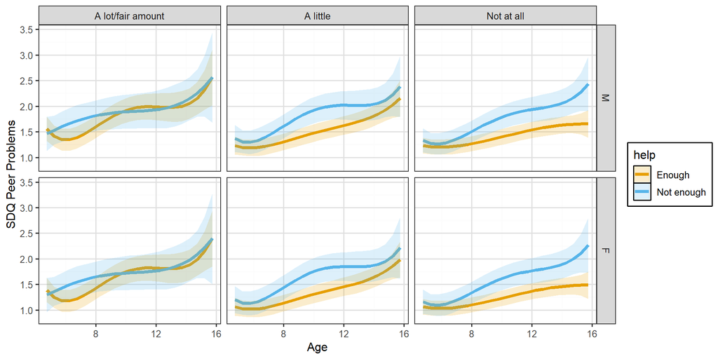

**Highest income plot**

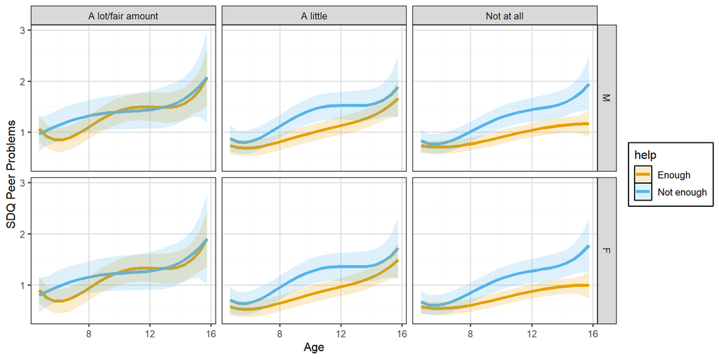

### Sex, income, maternal MH + SIMD

**Estimates**

[1] “No singular fit” [1] “No convergence issues”

| REML |
| --- |
| 41052.51 |

|  | Dsdpr1 |  |  |  |  |  |  |  |  |  |  |
| --- | --- | --- | --- | --- | --- | --- | --- | --- | --- | --- | --- |
| Predictors | Estimates | std. Error | std. Beta | standardized std. Error | CI | standardized CI | Statistic | std. Statistic | p | std. p | df |
| (Intercept) | 1.13 | 0.09 | -0.07 | 0.06 | 0.95 – 1.32 | -0.18 – 0.04 | 12.04 | -1.27 | **<0.001** | 0.203 | 12018.00 |
| food help [A little.Enough] | 0.08 | 0.07 | 0.05 | 0.04 | -0.07 – 0.22 | -0.04 – 0.13 | 1.02 | 1.02 | 0.309 | 0.310 | 12018.00 |
| food help [A little.Not enough] | 0.48 | 0.12 | 0.29 | 0.07 | 0.25 – 0.72 | 0.15 – 0.43 | 4.04 | 4.03 | **<0.001** | **<0.001** | 12018.00 |
| food help [A lot/fair amount.Enough] | 0.45 | 0.12 | 0.27 | 0.07 | 0.22 – 0.69 | 0.14 – 0.41 | 3.87 | 3.86 | **<0.001** | **<0.001** | 12018.00 |
| food help [A lot/fair amount.Not enough] | 0.51 | 0.16 | 0.31 | 0.10 | 0.19 – 0.83 | 0.12 – 0.50 | 3.15 | 3.15 | **0.002** | **0.002** | 12018.00 |
| food help [Not at all.Not enough] | 0.36 | 0.10 | 0.22 | 0.06 | 0.16 – 0.56 | 0.09 – 0.34 | 3.47 | 3.47 | **0.001** | **0.001** | 12018.00 |
| age cent | 0.07 | 0.01 | 0.15 | 0.03 | 0.04 – 0.10 | 0.09 – 0.20 | 5.18 | 5.16 | **<0.001** | **<0.001** | 12018.00 |
| age cent^2 | 0.00 | 0.01 | 0.02 | 0.04 | -0.01 – 0.01 | -0.06 – 0.10 | 0.54 | 0.55 | 0.591 | 0.583 | 12018.00 |
| age cent^3 | -0.00 | 0.00 | -0.03 | 0.02 | -0.00 – 0.00 | -0.07 – 0.00 | -1.76 | -1.75 | 0.078 | 0.080 | 12018.00 |
| age cent^4 | 0.00 | 0.00 | 0.00 | 0.02 | -0.00 – 0.00 | -0.03 – 0.04 | 0.23 | 0.23 | 0.821 | 0.821 | 12018.00 |
| Sex [F] | -0.17 | 0.05 | -0.10 | 0.03 | -0.26 – -0.08 | -0.16 – -0.05 | -3.77 | -3.77 | **<0.001** | **<0.001** | 12018.00 |
| DeEqv5 [2] | -0.15 | 0.08 | -0.09 | 0.05 | -0.30 – 0.00 | -0.18 – 0.00 | -1.92 | -1.92 | 0.054 | 0.054 | 12018.00 |
| DeEqv5 [3] | -0.16 | 0.08 | -0.10 | 0.05 | -0.32 – 0.00 | -0.19 – 0.00 | -1.94 | -1.94 | 0.053 | 0.053 | 12018.00 |
| DeEqv5 [4] | -0.33 | 0.08 | -0.20 | 0.05 | -0.49 – -0.17 | -0.29 – -0.10 | -4.10 | -4.10 | **<0.001** | **<0.001** | 12018.00 |
| DeEqv5 [5] | -0.35 | 0.09 | -0.21 | 0.05 | -0.52 – -0.18 | -0.32 – -0.11 | -3.98 | -3.98 | **<0.001** | **<0.001** | 12018.00 |
| DeSf12mn | -0.17 | 0.02 | -0.10 | 0.01 | -0.22 – -0.12 | -0.13 – -0.07 | -7.17 | -7.17 | **<0.001** | **<0.001** | 12018.00 |
| ALeSNim2 [2] | 0.11 | 0.07 | 0.07 | 0.04 | -0.02 – 0.24 | -0.01 – 0.14 | 1.61 | 1.61 | 0.108 | 0.108 | 12018.00 |
| ALeSNim2 [3] | 0.10 | 0.07 | 0.06 | 0.04 | -0.04 – 0.23 | -0.03 – 0.14 | 1.37 | 1.37 | 0.172 | 0.172 | 12018.00 |
| ALeSNim2 [4] | 0.24 | 0.08 | 0.14 | 0.05 | 0.09 – 0.38 | 0.05 – 0.23 | 3.10 | 3.10 | **0.002** | **0.002** | 12018.00 |
| ALeSNim2 [5] | 0.41 | 0.08 | 0.25 | 0.05 | 0.24 – 0.57 | 0.15 – 0.35 | 4.85 | 4.85 | **<0.001** | **<0.001** | 12018.00 |
| food help [A little.Enough] × age cent | 0.02 | 0.02 | 0.04 | 0.05 | -0.03 – 0.06 | -0.06 – 0.13 | 0.72 | 0.72 | 0.472 | 0.470 | 12018.00 |
| food help [A little.Not enough] × age cent | 0.08 | 0.04 | 0.17 | 0.08 | 0.01 – 0.15 | 0.01 – 0.32 | 2.11 | 2.12 | **0.035** | **0.034** | 12018.00 |
| food help [A lot/fair amount.Enough] × age cent | 0.08 | 0.03 | 0.17 | 0.07 | 0.02 – 0.15 | 0.03 – 0.32 | 2.42 | 2.44 | **0.015** | **0.015** | 12018.00 |
| food help [A lot/fair amount.Not enough] × age cent | -0.04 | 0.05 | -0.08 | 0.10 | -0.13 – 0.05 | -0.27 – 0.11 | -0.85 | -0.84 | 0.394 | 0.399 | 12018.00 |
| food help [Not at all.Not enough] × age cent | 0.07 | 0.03 | 0.14 | 0.07 | 0.00 – 0.13 | 0.00 – 0.28 | 2.02 | 2.03 | **0.043** | **0.043** | 12018.00 |
| food help [A little.Enough] × age cent^2 | -0.01 | 0.01 | -0.04 | 0.07 | -0.02 – 0.01 | -0.18 – 0.09 | -0.63 | -0.63 | 0.529 | 0.528 | 12018.00 |
| food help [A little.Not enough] × age cent^2 | -0.03 | 0.01 | -0.21 | 0.11 | -0.06 – 0.00 | -0.42 – 0.00 | -1.95 | -1.95 | 0.051 | 0.051 | 12018.00 |
| food help [A lot/fair amount.Enough] × age cent^2 | -0.03 | 0.01 | -0.24 | 0.10 | -0.06 – -0.01 | -0.43 – -0.04 | -2.39 | -2.38 | **0.017** | **0.017** | 12018.00 |
| food help [A lot/fair amount.Not enough] × age cent^2 | -0.01 | 0.02 | -0.10 | 0.14 | -0.05 – 0.03 | -0.38 – 0.19 | -0.66 | -0.67 | 0.509 | 0.504 | 12018.00 |
| food help [Not at all.Not enough] × age cent^2 | -0.02 | 0.01 | -0.13 | 0.10 | -0.04 – 0.01 | -0.32 – 0.05 | -1.40 | -1.40 | 0.162 | 0.162 | 12018.00 |
| food help [A little.Enough] × age cent^3 | 0.00 | 0.00 | 0.00 | 0.03 | -0.00 – 0.00 | -0.06 – 0.06 | 0.05 | 0.04 | 0.958 | 0.969 | 12018.00 |
| food help [A little.Not enough] × age cent^3 | -0.00 | 0.00 | -0.06 | 0.05 | -0.01 – 0.00 | -0.16 – 0.04 | -1.18 | -1.19 | 0.240 | 0.235 | 12018.00 |
| food help [A lot/fair amount.Enough] × age cent^3 | -0.00 | 0.00 | -0.10 | 0.05 | -0.01 – -0.00 | -0.19 – -0.00 | -2.04 | -2.06 | **0.041** | **0.039** | 12018.00 |
| food help [A lot/fair amount.Not enough] × age cent^3 | 0.00 | 0.00 | 0.08 | 0.06 | -0.00 – 0.01 | -0.04 – 0.20 | 1.28 | 1.26 | 0.200 | 0.207 | 12018.00 |
| food help [Not at all.Not enough] × age cent^3 | -0.00 | 0.00 | -0.04 | 0.05 | -0.00 – 0.00 | -0.13 – 0.05 | -0.86 | -0.87 | 0.392 | 0.386 | 12018.00 |
| food help [A little.Enough] × age cent^4 | 0.00 | 0.00 | 0.03 | 0.03 | -0.00 – 0.00 | -0.04 – 0.09 | 0.87 | 0.87 | 0.385 | 0.385 | 12018.00 |
| food help [A little.Not enough] × age cent^4 | 0.00 | 0.00 | 0.08 | 0.05 | -0.00 – 0.00 | -0.02 – 0.18 | 1.58 | 1.58 | 0.115 | 0.115 | 12018.00 |
| food help [A lot/fair amount.Enough] × age cent^4 | 0.00 | 0.00 | 0.12 | 0.05 | 0.00 – 0.00 | 0.02 – 0.21 | 2.46 | 2.46 | **0.014** | **0.014** | 12018.00 |
| food help [A lot/fair amount.Not enough] × age cent^4 | 0.00 | 0.00 | 0.02 | 0.07 | -0.00 – 0.00 | -0.12 – 0.15 | 0.25 | 0.25 | 0.804 | 0.804 | 12018.00 |
| food help [Not at all.Not enough] × age cent^4 | 0.00 | 0.00 | 0.06 | 0.05 | -0.00 – 0.00 | -0.03 – 0.15 | 1.32 | 1.32 | 0.186 | 0.186 | 12018.00 |
| Random Effects |  |  |  |  |  |  |  |  |  |  |  |
| σ<sup>2</sup> | 0.98 |  |  |  |  |  |  |  |  |  |  |
| τ<sub>00</sub> <sub>Idnumber</sub> | 1.02 |  |  |  |  |  |  |  |  |  |  |
| τ<sub>11</sub> <sub>Idnumber.age.cent</sub> | 0.02 |  |  |  |  |  |  |  |  |  |  |
| ρ<sub>01</sub> <sub>Idnumber</sub> | 0.51 |  |  |  |  |  |  |  |  |  |  |
| ICC | 0.56 |  |  |  |  |  |  |  |  |  |  |
| N <sub>Idnumber</sub> | 2035 |  |  |  |  |  |  |  |  |  |  |
| Observations | 12062 |  |  |  |  |  |  |  |  |  |  |
| Marginal R<sup>2</sup> / Conditional R<sup>2</sup> | 0.078 / 0.596 |  |  |  |  |  |  |  |  |  |  |

**Contrasts**

| Age | contrast | null.value | estimate | std.error | df | statistic | p.value |
| --- | --- | --- | --- | --- | --- | --- | --- |
| 5 | Not at all.Not enough vs Enough | 0 | 0.087 | 0.096 | 3203.182 | 0.915 | 0.360 |
| 5 | A little.Not enough vs Enough | 0 | 0.109 | 0.116 | 3064.045 | 0.945 | 0.345 |
| 5 | A lot/fair amount.Not enough vs Enough | 0 | 0.033 | 0.171 | 2466.542 | 0.194 | 0.846 |
| 6 | Not at all.Not enough vs Enough | 0 | 0.079 | 0.097 | 3985.011 | 0.813 | 0.416 |
| 6 | A little.Not enough vs Enough | 0 | 0.112 | 0.117 | 3806.633 | 0.951 | 0.341 |
| 6 | A lot/fair amount.Not enough vs Enough | 0 | 0.298 | 0.174 | 3138.269 | 1.717 | 0.086 |
| 7 | Not at all.Not enough vs Enough | 0 | 0.152 | 0.099 | 4498.435 | 1.539 | 0.124 |
| 7 | A little.Not enough vs Enough | 0 | 0.192 | 0.119 | 4283.036 | 1.612 | 0.107 |
| 7 | A lot/fair amount.Not enough vs Enough | 0 | 0.325 | 0.176 | 3525.707 | 1.848 | 0.065 |
| 8 | Not at all.Not enough vs Enough | 0 | 0.252 | 0.096 | 3950.158 | 2.627 | 0.009 |
| 8 | A little.Not enough vs Enough | 0 | 0.298 | 0.116 | 3779.645 | 2.559 | 0.011 |
| 8 | A lot/fair amount.Not enough vs Enough | 0 | 0.227 | 0.173 | 3203.413 | 1.311 | 0.190 |
| 9 | Not at all.Not enough vs Enough | 0 | 0.341 | 0.102 | 4195.879 | 3.354 | 0.001 |
| 9 | A little.Not enough vs Enough | 0 | 0.388 | 0.123 | 4039.098 | 3.142 | 0.002 |
| 9 | A lot/fair amount.Not enough vs Enough | 0 | 0.092 | 0.184 | 3456.182 | 0.500 | 0.617 |
| 10 | Not at all.Not enough vs Enough | 0 | 0.398 | 0.108 | 4175.054 | 3.676 | 0.000 |
| 10 | A little.Not enough vs Enough | 0 | 0.438 | 0.132 | 4038.769 | 3.330 | 0.001 |
| 10 | A lot/fair amount.Not enough vs Enough | 0 | -0.018 | 0.196 | 3412.880 | -0.091 | 0.927 |
| 11 | Not at all.Not enough vs Enough | 0 | 0.418 | 0.111 | 3486.129 | 3.753 | 0.000 |
| 11 | A little.Not enough vs Enough | 0 | 0.437 | 0.135 | 3393.845 | 3.226 | 0.001 |
| 11 | A lot/fair amount.Not enough vs Enough | 0 | -0.068 | 0.202 | 2884.643 | -0.338 | 0.735 |
| 12 | Not at all.Not enough vs Enough | 0 | 0.411 | 0.118 | 3142.191 | 3.477 | 0.001 |
| 12 | A little.Not enough vs Enough | 0 | 0.386 | 0.144 | 3078.949 | 2.689 | 0.007 |
| 12 | A lot/fair amount.Not enough vs Enough | 0 | -0.051 | 0.217 | 2706.705 | -0.234 | 0.815 |
| 13 | Not at all.Not enough vs Enough | 0 | 0.403 | 0.130 | 3246.871 | 3.095 | 0.002 |
| 13 | A little.Not enough vs Enough | 0 | 0.304 | 0.159 | 3189.387 | 1.919 | 0.055 |
| 13 | A lot/fair amount.Not enough vs Enough | 0 | 0.017 | 0.240 | 2826.453 | 0.071 | 0.943 |
| 14 | Not at all.Not enough vs Enough | 0 | 0.440 | 0.136 | 2779.487 | 3.226 | 0.001 |
| 14 | A little.Not enough vs Enough | 0 | 0.222 | 0.165 | 2708.356 | 1.341 | 0.180 |
| 14 | A lot/fair amount.Not enough vs Enough | 0 | 0.091 | 0.250 | 2365.388 | 0.365 | 0.715 |
| 15 | Not at all.Not enough vs Enough | 0 | 0.579 | 0.168 | 4097.136 | 3.450 | 0.001 |
| 15 | A little.Not enough vs Enough | 0 | 0.184 | 0.200 | 3807.113 | 0.921 | 0.357 |
| 15 | A lot/fair amount.Not enough vs Enough | 0 | 0.101 | 0.307 | 3624.281 | 0.329 | 0.742 |
| 16 | Not at all.Not enough vs Enough | 0 | 0.896 | 0.361 | 10461.335 | 2.485 | 0.013 |
| 16 | A little.Not enough vs Enough | 0 | 0.250 | 0.426 | 10405.590 | 0.587 | 0.557 |
| 16 | A lot/fair amount.Not enough vs Enough | 0 | -0.050 | 0.653 | 10421.904 | -0.077 | 0.939 |

**Lowest income plot**

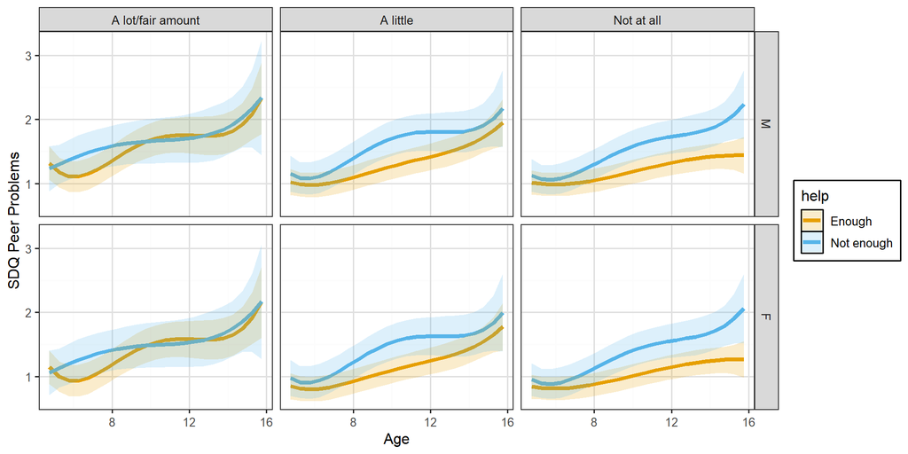

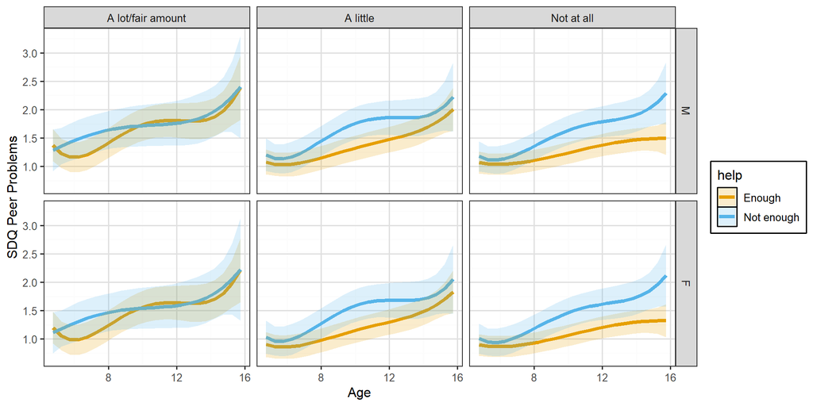